# PDO Survey Dashboard v2

RAMANAGARA

KANAKAPURA

HERINDYAPANAHALLI

Not Surveyed

RAMANAGARA

KANAKAPURA

HOSADURGA

Not Surveyed

RAMANAGARA

KANAKAPURA

HONNIGANAHALLI

Not Surveyed

RAMANAGARA

KANAKAPURA

I.GOLLAHALLI

Not Surveyed

RAMANAGARA

KANAKAPURA

CHIKKAMUDHUVADI

Not Surveyed

RAMANAGARA

KANAKAPURA

CHEELURU

Not Surveyed

RAMANAGARA

MAGADI

ADARANGI

Surveyed

RAMANAGARA

MAGADI

AGALAKOTE

Surveyed

RAMANAGARA

MAGADI

AJJANAHALLI

Surveyed

RAMANAGARA

MAGADI

HANCHIKUPPE

Surveyed

RAMANAGARA

MAGADI

HULLENAHALLI

Surveyed

RAMANAGARA

MAGADI

MADIGONDANAHALLI

Surveyed

RAMANAGARA

MAGADI

NARASANDRA

Surveyed

RAMANAGARA

MAGADI

SATHANOOR

Surveyed

RAMANAGARA

MAGADI

BACHENAHATTI

Not Surveyed

RAMANAGARA

MAGADI

BANAVADI

Not Surveyed

RAMANAGARA

MAGADI

BELAGUMBA

Not Surveyed

RAMANAGARA

MAGADI

BISKOOR

Not Surveyed

RAMANAGARA

MAGADI

BITTASANDRA

Not Surveyed

RAMANAGARA

MAGADI

CHIKKAHALLI

Not Surveyed

RAMANAGARA

MAGADI

CHIKKAMUDIGERE

Not Surveyed

RAMANAGARA

MAGADI

GUDEMARANAHALLI

Not Surveyed

RAMANAGARA

MAGADI

HHULIKALLU

Not Surveyed

RAMANAGARA

MAGADI

KALARI KAVAL

Not Surveyed

RAMANAGARA

MAGADI

KKALYA

Not Surveyed

RAMANAGARA

MAGADI

KANNURU

Not Surveyed

RAMANAGARA

MAGADI

KUDUR

Not Surveyed

RAMANAGARA

MAGADI

LLAKKENAHALLI

Not Surveyed

RAMANAGARA

MAGADI

MADABAL

Not Surveyed

RAMANAGARA

MAGADI

MATHIKERE

Not Surveyed

RAMANAGARA

MAGADI

MOTAGONDANAHALLI

Not Surveyed

RAMANAGARA

MAGADI

NETHANAHALLI

Not Surveyed

RAMANAGARA

MAGADI

SANKIGATTA

Not Surveyed

RAMANAGARA

MAGADI

SEEGEKUPPE

Not Surveyed

RAMANAGARA

MAGADI

SOLUR

Not Surveyed

RAMANAGARA

MAGADI

SRIGIRIPURA

Not Surveyed

RAMANAGARA

MAGADI

THAGGIKUPPE

Not Surveyed

RAMANAGARA

MAGADI

THIPPASANDRA

Not Surveyed

RAMANAGARA

RAMANAGARA

BANNIKUPPE (K)

Surveyed

RAMANAGARA

RAMANAGARA

BANNIKUPPE (B)

Surveyed

RAMANAGARA

RAMANAGARA

HULIKERE GUNNUR

Surveyed

RAMANAGARA

RAMANAGARA

HUNASANAHALLI

Surveyed

RAMANAGARA

RAMANAGARA

AKKURU

Not Surveyed

RAMANAGARA

RAMANAGARA

BILAGUMBA

Not Surveyed

RAMANAGARA

RAMANAGARA

BYRAMANGALA

Not Surveyed

RAMANAGARA

RAMANAGARA

DODDAGANGAVADI

Not Surveyed

RAMANAGARA

RAMANAGARA

GOPAHALLI

Not Surveyed

RAMANAGARA

RAMANAGARA

HARISANDRA

Not Surveyed

RAMANAGARA

RAMANAGARA

JALAMANGALA

Not Surveyed

RAMANAGARA

RAMANAGARA

KAILANCHA

Not Surveyed

RAMANAGARA

RAMANAGARA

KANCHUGARANA HALLI

Not Surveyed

RAMANAGARA

RAMANAGARA

KUTAGAL

Not Surveyed

RAMANAGARA

RAMANAGARA

LAKSHMIPURA

Not Surveyed

RAMANAGARA

RAMANAGARA

MANCHANAYAKANA HALLY

Not Surveyed

RAMANAGARA

RAMANAGARA

MAYAGANAHALLI

Not Surveyed

RAMANAGARA

RAMANAGARA

SHYNUBHOGANAHALLI

Not Surveyed

RAMANAGARA

RAMANAGARA

SUGGANAHALLI

Not Surveyed

RAMANAGARA

RAMANAGARA

VIBHUTHIKERE

Not Surveyed

SHIVAMOGGA

BHADRAVATI

DASARAKALLAHALLI

Surveyed

SHIVAMOGGA

BHADRAVATI

KALLAHALLI

Surveyed

SHIVAMOGGA

BHADRAVATI

SYDARAKALLAHALLI

Surveyed

SHIVAMOGGA

BHADRAVATI

SIDLIPURA

Surveyed

SHIVAMOGGA

BHADRAVATI

ARALIHALLI

Surveyed

SHIVAMOGGA

BHADRAVATI

ARAHATHOLALU

Surveyed

SHIVAMOGGA

BHADRAVATI

NIMBEGONDI

Surveyed

SHIVAMOGGA

BHADRAVATI

VEERAPURA

Surveyed

SHIVAMOGGA

BHADRAVATI

TADASA

Surveyed

SHIVAMOGGA

BHADRAVATI

ATTIGUNDA

Surveyed

SHIVAMOGGA

BHADRAVATI

KUDLIGERE

Surveyed

SHIVAMOGGA

BHADRAVATI

DONABAGATTA

Surveyed

SHIVAMOGGA

BHADRAVATI

KAMBADAL HOSURU

Surveyed

SHIVAMOGGA

BHADRAVATI

GUDAMAGATTA

Surveyed

SHIVAMOGGA

BHADRAVATI

YEDEHALLI

Surveyed

SHIVAMOGGA

BHADRAVATI

MARASHETTIHALLI

Surveyed

SHIVAMOGGA

BHADRAVATI

AREBILACHI

Surveyed

SHIVAMOGGA

BHADRAVATI

NAGATHIBELAGALU

Surveyed

SHIVAMOGGA

BHADRAVATI

TAVARAGATTA

Surveyed

SHIVAMOGGA

BHADRAVATI

MAVINKERE

Surveyed

SHIVAMOGGA

BHADRAVATI

MANGOTE

Surveyed

SHIVAMOGGA

BHADRAVATI

ARAKERE

Surveyed

SHIVAMOGGA

BHADRAVATI

BARANDUR

Surveyed

SHIVAMOGGA

BHADRAVATI

BILAKI

Surveyed

SHIVAMOGGA

BHADRAVATI

KAGEKODAMAGGE

Surveyed

SHIVAMOGGA

BHADRAVATI

SINGANAMANE

Surveyed

SHIVAMOGGA

BHADRAVATI

ANAVERI

Surveyed

SHIVAMOGGA

BHADRAVATI

AGARADAHALLI

Surveyed

SHIVAMOGGA

BHADRAVATI

DODDERI

Surveyed

SHIVAMOGGA

BHADRAVATI

MYDOLALU

Surveyed

SHIVAMOGGA

BHADRAVATI

HOLEHONNURU

Not Surveyed

SHIVAMOGGA

BHADRAVATI

EMMEHATTI

Not Surveyed

SHIVAMOGGA

BHADRAVATI

YAREHALLI

Not Surveyed

SHIVAMOGGA

BHADRAVATI

ANTHARAGANGE

Not Surveyed

SHIVAMOGGA

BHADRAVATI

ARALIKOPPA

Not Surveyed

SHIVAMOGGA

BHADRAVATI

KAREHALLI

Not Surveyed

SHIVAMOGGA

BHADRAVATI

KALLIHAL

Not Surveyed

SHIVAMOGGA

BHADRAVATI

HIRIYURU

Not Surveyed

SHIVAMOGGA

BHADRAVATI

KOMMARANAHALLI

Not Surveyed

SHIVAMOGGA

BHADRAVATI

HANUMANTHAPURA

Not Surveyed

SHIVAMOGGA

BHADRAVATI

SANYASIKODAMAGGE

Not Surveyed

SHIVAMOGGA

HOSANAGARA

THIRNIVE

Surveyed

SHIVAMOGGA

HOSANAGARA

KARIMANE

Surveyed

SHIVAMOGGA

HOSANAGARA

KENCHANALA

Surveyed

SHIVAMOGGA

HOSANAGARA

KODUR

Surveyed

SHIVAMOGGA

HOSANAGARA

PURAPPEMANE

Surveyed

SHIVAMOGGA

HOSANAGARA

JENI

Surveyed

SHIVAMOGGA

HOSANAGARA

BALUR

Surveyed

SHIVAMOGGA

HOSANAGARA

MELINABESIGE

Surveyed

SHIVAMOGGA

HOSANAGARA

SULUGODU

Surveyed

SHIVAMOGGA

HOSANAGARA

SONALE

Surveyed

SHIVAMOGGA

HOSANAGARA

ARAMANEKOPPA

Surveyed

SHIVAMOGGA

HOSANAGARA

ARASALU

Surveyed

SHIVAMOGGA

HOSANAGARA

ANDAGADUDURU

Surveyed

SHIVAMOGGA

HOSANAGARA

AMRUTHA

Surveyed

SHIVAMOGGA

HOSANAGARA

HARATHALU

Surveyed

SHIVAMOGGA

HOSANAGARA

HEDDARIPURA

Surveyed

SHIVAMOGGA

HOSANAGARA

HOSURU

Surveyed

SHIVAMOGGA

HOSANAGARA

NITTURU

Surveyed

SHIVAMOGGA

HOSANAGARA

CHIKKAJENI

Surveyed

SHIVAMOGGA

HOSANAGARA

M.GUDDEKOPPA

Surveyed

SHIVAMOGGA

HOSANAGARA

RAMACHANDRAPURA

Surveyed

SHIVAMOGGA

HOSANAGARA

YADURU

Not Surveyed

SHIVAMOGGA

HOSANAGARA

KAIRAGUNDA

Not Surveyed

SHIVAMOGGA

HOSANAGARA

RIPPONPETE

Not Surveyed

SHIVAMOGGA

HOSANAGARA

BELLURU

Not Surveyed

SHIVAMOGGA

HOSANAGARA

MARUTHIPURA

Not Surveyed

SHIVAMOGGA

HOSANAGARA

MUDUGOPPA-NAGARA

Not Surveyed

SHIVAMOGGA

HOSANAGARA

MUMBARU

Not Surveyed

SHIVAMOGGA

HOSANAGARA

HARIDRAVATHI

Not Surveyed

SHIVAMOGGA

HOSANAGARA

HUMCHA

Not Surveyed

SHIVAMOGGA

SAGAR

SYDURU

Surveyed

SHIVAMOGGA

SAGAR

THYAGARTHI

Surveyed

SHIVAMOGGA

SAGAR

TUMARI

Surveyed

SHIVAMOGGA

SAGAR

ACHAPURA

Surveyed

SHIVAMOGGA

SAGAR

BARURU

Surveyed

SHIVAMOGGA

SAGAR

BHEEMANAKONE

Surveyed

SHIVAMOGGA

SAGAR

CHANNAGONDA

Surveyed

SHIVAMOGGA

SAGAR

HEGGODU

Surveyed

SHIVAMOGGA

SAGAR

HOSURU

Surveyed

SHIVAMOGGA

SAGAR

KHANDIKA

Surveyed

SHIVAMOGGA

SAGAR

NADAKALSI

Surveyed

SHIVAMOGGA

SAGAR

TALAVATA

Surveyed

SHIVAMOGGA

SAGAR

ULLURU

Surveyed

SHIVAMOGGA

SAGAR

YADAJIGALEMANE

Surveyed

SHIVAMOGGA

SAGAR

KOLURU

Not Surveyed

SHIVAMOGGA

SAGAR

KELADI

Not Surveyed

SHIVAMOGGA

SAGAR

HIREBILAGUNJI

Not Surveyed

SHIVAMOGGA

SAGAR

ANANDAPURA

Not Surveyed

SHIVAMOGGA

SAGAR

ARALAGODU

Not Surveyed

SHIVAMOGGA

SAGAR

AVINAHALLI

Not Surveyed

SHIVAMOGGA

SAGAR

BHANUKULI

Not Surveyed

SHIVAMOGGA

SAGAR

BHIMANERI

Not Surveyed

SHIVAMOGGA

SAGAR

GOWTHAMPURA

Not Surveyed

SHIVAMOGGA

SAGAR

HIRENELLURU

Not Surveyed

SHIVAMOGGA

SAGAR

KALMANE

Not Surveyed

SHIVAMOGGA

SAGAR

KANLE

Not Surveyed

SHIVAMOGGA

SAGAR

KUDARURU

Not Surveyed

SHIVAMOGGA

SAGAR

MALVE

Not Surveyed

SHIVAMOGGA

SAGAR

MARTHURU

Not Surveyed

SHIVAMOGGA

SAGAR

MASURU

Not Surveyed

SHIVAMOGGA

SAGAR

PADAVAGODU

Not Surveyed

SHIVAMOGGA

SAGAR

S.S.BHOG

Not Surveyed

SHIVAMOGGA

SAGAR

SHIRAVANTHE

Not Surveyed

SHIVAMOGGA

SAGAR

TALAGUPPA

Not Surveyed

SHIVAMOGGA

SAGAR

YEDEHALLI

Not Surveyed

SHIVAMOGGA

SHIKARIPUR

MARAVALLI

Surveyed

SHIVAMOGGA

SHIKARIPUR

BAGANAKATTE

Surveyed

SHIVAMOGGA

SHIKARIPUR

KAGINALLI

Surveyed

SHIVAMOGGA

SHIKARIPUR

HOSURU

Surveyed

SHIVAMOGGA

SHIKARIPUR

JAKKANAHALLI

Surveyed

SHIVAMOGGA

SHIKARIPUR

HAROGOPPA

Surveyed

SHIVAMOGGA

SHIKARIPUR

HITHALA

Surveyed

SHIVAMOGGA

SHIKARIPUR

ARISHINAGERE

Surveyed

SHIVAMOGGA

SHIKARIPUR

CHURCHIGUNDI

Surveyed

SHIVAMOGGA

SHIKARIPUR

UDUGANI

Surveyed

SHIVAMOGGA

SHIKARIPUR

GUDDADA THUMMINAKATTE

Surveyed

SHIVAMOGGA

SHIKARIPUR

INAM AGRAHARAMUCHADI

Surveyed

SHIVAMOGGA

SHIKARIPUR

BILIKI

Surveyed

SHIVAMOGGA

SHIKARIPUR

NARASAPURA

Surveyed

SHIVAMOGGA

SHIKARIPUR

HARAGI

Surveyed

SHIVAMOGGA

SHIKARIPUR

BELLIGAVI

Surveyed

SHIVAMOGGA

SHIKARIPUR

MATTHIKOTE

Surveyed

SHIVAMOGGA

SHIKARIPUR

CHIKKAMAGADI

Surveyed

SHIVAMOGGA

SHIKARIPUR

GODDANAKOPPA

Surveyed

SHIVAMOGGA

SHIKARIPUR

HOTHANA KATTE

Surveyed

SHIVAMOGGA

SHIKARIPUR

KITTADAHALLI

Not Surveyed

SHIVAMOGGA

SHIKARIPUR

JAKKINAKOPPA

Not Surveyed

SHIVAMOGGA

SHIKARIPUR

GOGGA

Not Surveyed

SHIVAMOGGA

SHIKARIPUR

MUDDANAHALLI

Not Surveyed

SHIVAMOGGA

SHIKARIPUR

BEGURU

Not Surveyed

SHIVAMOGGA

SHIKARIPUR

SALURU

Not Surveyed

SHIVAMOGGA

SHIKARIPUR

KAPPANAHALLI

Not Surveyed

SHIVAMOGGA

SHIKARIPUR

MUDUBASIDDAPURA

Not Surveyed

SHIVAMOGGA

SHIKARIPUR

AMATEKOPPA

Not Surveyed

SHIVAMOGGA

SHIKARIPUR

GAMA

Not Surveyed

SHIVAMOGGA

SHIKARIPUR

ESURU

Not Surveyed

SHIVAMOGGA

SHIKARIPUR

CHIKKAJAMBURU

Not Surveyed

SHIVAMOGGA

SHIKARIPUR

SUNNADAKOPPA

Not Surveyed

SHIVAMOGGA

SHIKARIPUR

MANCHIKOPPA

Not Surveyed

SHIVAMOGGA

SHIKARIPUR

AMBARAGOPPA

Not Surveyed

SHIVAMOGGA

SHIKARIPUR

HIREJAMBURU

Not Surveyed

SHIVAMOGGA

SHIKARIPUR

KORATIGERE

Not Surveyed

SHIVAMOGGA

SHIKARIPUR

MALAVALLI

Not Surveyed

SHIVAMOGGA

SHIKARIPUR

THOGARSI

Not Surveyed

SHIVAMOGGA

SHIKARIPUR

THALAGUNDA

Not Surveyed

SHIVAMOGGA

SHIKARIPUR

NELAVAGILU

Not Surveyed

SHIVAMOGGA

SHIKARIPUR

KALMANE

Not Surveyed

SHIVAMOGGA

SHIKARIPUR

THADAGANI

Not Surveyed

SHIVAMOGGA

SHIKARIPUR

THARLAGHATTA

Not Surveyed

SHIVAMOGGA

SHIVAMOGGA

BALEKOPPA

Surveyed

SHIVAMOGGA

SHIVAMOGGA

HASUDI

Surveyed

SHIVAMOGGA

SHIVAMOGGA

HOLALURU

Surveyed

SHIVAMOGGA

SHIVAMOGGA

HOLEBENAVANAHALLI

Surveyed

SHIVAMOGGA

SHIVAMOGGA

KADEKAL

Surveyed

SHIVAMOGGA

SHIVAMOGGA

KORALAHALLI

Surveyed

SHIVAMOGGA

SHIVAMOGGA

MATTURU

Surveyed

SHIVAMOGGA

SHIVAMOGGA

SANTEKADURU

Surveyed

SHIVAMOGGA

SHIVAMOGGA

SUGURU

Surveyed

SHIVAMOGGA

SHIVAMOGGA

ABBALAGERE

Surveyed

SHIVAMOGGA

SHIVAMOGGA

AGASAVALLI

Surveyed

SHIVAMOGGA

SHIVAMOGGA

MANDAGATTA

Surveyed

SHIVAMOGGA

SHIVAMOGGA

NIDHIGE

Surveyed

SHIVAMOGGA

SHIVAMOGGA

PILLANGERE

Surveyed

SHIVAMOGGA

SHIVAMOGGA

RAMANAGARA

Surveyed

SHIVAMOGGA

SHIVAMOGGA

SIRIGERE

Surveyed

SHIVAMOGGA

SHIVAMOGGA

UMBLEBAILU

Surveyed

SHIVAMOGGA

SHIVAMOGGA

SHETTIHALLI

Surveyed

SHIVAMOGGA

SHIVAMOGGA

KOHALLI

Surveyed

SHIVAMOGGA

SHIVAMOGGA

MUDDINAKOPPA

Surveyed

SHIVAMOGGA

SHIVAMOGGA

TUPPURU

Surveyed

SHIVAMOGGA

SHIVAMOGGA

HARANAHALLI

Not Surveyed

SHIVAMOGGA

SHIVAMOGGA

HARAMAGHATTA

Not Surveyed

SHIVAMOGGA

SHIVAMOGGA

HOSAHALLI

Not Surveyed

SHIVAMOGGA

SHIVAMOGGA

KOMMANALU

Not Surveyed

SHIVAMOGGA

SHIVAMOGGA

B.BEERANAHALLI

Not Surveyed

SHIVAMOGGA

SHIVAMOGGA

BIDIRE

Not Surveyed

SHIVAMOGGA

SHIVAMOGGA

CHORADI

Not Surveyed

SHIVAMOGGA

SHIVAMOGGA

GHAJANURU

Not Surveyed

SHIVAMOGGA

SHIVAMOGGA

HADONAHALLI

Not Surveyed

SHIVAMOGGA

SHIVAMOGGA

KUMSI

Not Surveyed

SHIVAMOGGA

SHIVAMOGGA

KUNCHENAHALLI

Not Surveyed

SHIVAMOGGA

SHIVAMOGGA

MALLAPURA

Not Surveyed

SHIVAMOGGA

SHIVAMOGGA

KUDLI

Not Surveyed

SHIVAMOGGA

SHIVAMOGGA

KONAGAVALLI

Not Surveyed

SHIVAMOGGA

SHIVAMOGGA

KOTEGANGURU

Not Surveyed

SHIVAMOGGA

SHIVAMOGGA

MELINAHANASAVADI

Not Surveyed

SHIVAMOGGA

SHIVAMOGGA

AYANURU

Not Surveyed

SHIVAMOGGA

SHIVAMOGGA

TAMMADIHALLI

Not Surveyed

SHIVAMOGGA

SHIVAMOGGA

PURUDALU

Not Surveyed

SHIVAMOGGA

SHIVAMOGGA

BEDARA HOSAHALLI

Not Surveyed

SHIVAMOGGA

SHIVAMOGGA

SOGANE

Not Surveyed

SHIVAMOGGA

SORABA

THELAGUNDA

Surveyed

SHIVAMOGGA

SORABA

KUBTURU

Surveyed

SHIVAMOGGA

SORABA

ANAVATTI

Surveyed

SHIVAMOGGA

SORABA

TALLURU

Surveyed

SHIVAMOGGA

SORABA

KATUVALLI

Surveyed

SHIVAMOGGA

SORABA

TATTURU

Surveyed

SHIVAMOGGA

SORABA

KUPPAGADDE

Surveyed

SHIVAMOGGA

SORABA

UDRI

Surveyed

SHIVAMOGGA

SORABA

NYARSHI

Surveyed

SHIVAMOGGA

SORABA

HECHHE

Surveyed

SHIVAMOGGA

SORABA

HALESORABA

Surveyed

SHIVAMOGGA

SORABA

MUTUGUPPE

Surveyed

SHIVAMOGGA

SORABA

NISARANI

Surveyed

SHIVAMOGGA

SORABA

HOSABALE

Surveyed

SHIVAMOGGA

SORABA

DUGURU

Surveyed

SHIVAMOGGA

SORABA

SHAKUNAVALLI

Not Surveyed

SHIVAMOGGA

SORABA

MUDIDODDIKOPPA

Not Surveyed

SHIVAMOGGA

SORABA

AGASANAHALLI

Not Surveyed

SHIVAMOGGA

SORABA

TALAGADDE

Not Surveyed

SHIVAMOGGA

SORABA

JADE

Not Surveyed

SHIVAMOGGA

SORABA

BHARANGI

Not Surveyed

SHIVAMOGGA

SORABA

HANCHI

Not Surveyed

SHIVAMOGGA

SORABA

ENNEKOPPA

Not Surveyed

SHIVAMOGGA

SORABA

SAMANAVALLI

Not Surveyed

SHIVAMOGGA

SORABA

HARISHI

Not Surveyed

SHIVAMOGGA

SORABA

BENNURU

Not Surveyed

SHIVAMOGGA

SORABA

DYAVANAHALLI

Not Surveyed

SHIVAMOGGA

SORABA

GENDLA

Not Surveyed

SHIVAMOGGA

SORABA

TAVANANDI

Not Surveyed

SHIVAMOGGA

SORABA

GUDAVI

Not Surveyed

SHIVAMOGGA

SORABA

CHANDRAGUTTI

Not Surveyed

SHIVAMOGGA

SORABA

KODAKANI

Not Surveyed

SHIVAMOGGA

SORABA

MAVALI

Not Surveyed

SHIVAMOGGA

SORABA

BILUVANI

Not Surveyed

SHIVAMOGGA

SORABA

HEGGODU

Not Surveyed

SHIVAMOGGA

SORABA

CHITTURU

Not Surveyed

SHIVAMOGGA

SORABA

SHIGGA

Not Surveyed

SHIVAMOGGA

SORABA

INDUVALLI

Not Surveyed

SHIVAMOGGA

SORABA

ULAVI

Not Surveyed

SHIVAMOGGA

SORABA

HURULI

Not Surveyed

SHIVAMOGGA

SORABA

ANDIGE

Not Surveyed

SHIVAMOGGA

TIRTHAHALLI

MELINAKURUVALLI

Surveyed

SHIVAMOGGA

TIRTHAHALLI

ARAGA

Surveyed

SHIVAMOGGA

TIRTHAHALLI

SALURU

Surveyed

SHIVAMOGGA

TIRTHAHALLI

HOSAHALLI

Surveyed

SHIVAMOGGA

TIRTHAHALLI

DEVANGI

Surveyed

SHIVAMOGGA

TIRTHAHALLI

MELIGE

Surveyed

SHIVAMOGGA

TIRTHAHALLI

HEDDURU

Surveyed

SHIVAMOGGA

TIRTHAHALLI

BASAVANI

Surveyed

SHIVAMOGGA

TIRTHAHALLI

HAROGOLIGE

Surveyed

SHIVAMOGGA

TIRTHAHALLI

KONANDURU

Surveyed

SHIVAMOGGA

TIRTHAHALLI

NONABURU

Surveyed

SHIVAMOGGA

TIRTHAHALLI

ARALASURALI

Surveyed

SHIVAMOGGA

TIRTHAHALLI

THRIYAMBAKAPURA

Surveyed

SHIVAMOGGA

TIRTHAHALLI

SHINGANABIDARE

Surveyed

SHIVAMOGGA

TIRTHAHALLI

KANNANGI

Surveyed

SHIVAMOGGA

TIRTHAHALLI

BEJJAVALLI

Surveyed

SHIVAMOGGA

TIRTHAHALLI

THUDURU

Surveyed

SHIVAMOGGA

TIRTHAHALLI

AGUMBE

Surveyed

SHIVAMOGGA

TIRTHAHALLI

BIDARAGODU

Surveyed

SHIVAMOGGA

TIRTHAHALLI

MEGARAVALLI

Surveyed

SHIVAMOGGA

TIRTHAHALLI

HEGGODU

Surveyed

SHIVAMOGGA

TIRTHAHALLI

THIRTHAMUTTHURU

Surveyed

SHIVAMOGGA

TIRTHAHALLI

NERATURU

Surveyed

SHIVAMOGGA

TIRTHAHALLI

MULUBAGILU

Not Surveyed

SHIVAMOGGA

TIRTHAHALLI

HODALA (ARALAPURA)

Not Surveyed

SHIVAMOGGA

TIRTHAHALLI

SALGADI

Not Surveyed

SHIVAMOGGA

TIRTHAHALLI

SHEDGARU

Not Surveyed

SHIVAMOGGA

TIRTHAHALLI

HUMCHADAKATTE

Not Surveyed

SHIVAMOGGA

TIRTHAHALLI

GUDDEKOPPA

Not Surveyed

SHIVAMOGGA

TIRTHAHALLI

DEMLAPURA

Not Surveyed

SHIVAMOGGA

TIRTHAHALLI

HADIGALLU

Not Surveyed

SHIVAMOGGA

TIRTHAHALLI

MANDAGADDE

Not Surveyed

SHIVAMOGGA

TIRTHAHALLI

HANAGERE

Not Surveyed

SHIVAMOGGA

TIRTHAHALLI

BANDYA

Not Surveyed

SHIVAMOGGA

TIRTHAHALLI

KUDUMALLIGE

Not Surveyed

SHIVAMOGGA

TIRTHAHALLI

AREHALLI

Not Surveyed

SHIVAMOGGA

TIRTHAHALLI

HONNETHALU

Not Surveyed

SHIVAMOGGA

TIRTHAHALLI

NALURU (KOLAGI)

Not Surveyed

TUMAKURU

CHIKNAYAKANHALLI

HOYSALAKATTE

Surveyed

TUMAKURU

CHIKNAYAKANHALLI

HANDANAKERE

Surveyed

TUMAKURU

CHIKNAYAKANHALLI

BARAKANALU

Surveyed

TUMAKURU

CHIKNAYAKANHALLI

HONNEBAGI

Surveyed

TUMAKURU

CHIKNAYAKANHALLI

DASODI

Not Surveyed

TUMAKURU

CHIKNAYAKANHALLI

GANADALU

Not Surveyed

TUMAKURU

CHIKNAYAKANHALLI

KENKERE

Not Surveyed

TUMAKURU

CHIKNAYAKANHALLI

YALANADU

Not Surveyed

TUMAKURU

CHIKNAYAKANHALLI

KORAGERE

Not Surveyed

TUMAKURU

CHIKNAYAKANHALLI

DODDENNEGERE

Not Surveyed

TUMAKURU

CHIKNAYAKANHALLI

CHOWLAKATTE

Not Surveyed

TUMAKURU

CHIKNAYAKANHALLI

THIMMALAPURA

Not Surveyed

TUMAKURU

CHIKNAYAKANHALLI

DODDABIDARE

Not Surveyed

TUMAKURU

CHIKNAYAKANHALLI

THIMMANAHALLI

Not Surveyed

TUMAKURU

CHIKNAYAKANHALLI

RAMANAHALLI

Not Surveyed

TUMAKURU

CHIKNAYAKANHALLI

KANDIKERE

Not Surveyed

TUMAKURU

CHIKNAYAKANHALLI

BELAGULI

Not Surveyed

TUMAKURU

CHIKNAYAKANHALLI

BARAGUR

Not Surveyed

TUMAKURU

CHIKNAYAKANHALLI

MATHIGHATTA

Not Surveyed

TUMAKURU

CHIKNAYAKANHALLI

MALLIGERE

Not Surveyed

TUMAKURU

CHIKNAYAKANHALLI

KUPPUR

Not Surveyed

TUMAKURU

CHIKNAYAKANHALLI

SHETTIKERE

Not Surveyed

TUMAKURU

CHIKNAYAKANHALLI

DUGUDIHALLI

Not Surveyed

TUMAKURU

CHIKNAYAKANHALLI

MUDDENAHALLI

Not Surveyed

TUMAKURU

CHIKNAYAKANHALLI

THEERTHAPURA

Not Surveyed

TUMAKURU

CHIKNAYAKANHALLI

GODEKERE

Not Surveyed

TUMAKURU

CHIKNAYAKANHALLI

J.C.PURA

Not Surveyed

TUMAKURU

GUBBI

ANKASANDRA

Surveyed

TUMAKURU

GUBBI

ALILAGHATTA

Surveyed

TUMAKURU

GUBBI

DODDAGUNI

Surveyed

TUMAKURU

GUBBI

BELAVETHA

Surveyed

TUMAKURU

GUBBI

PEDDANAHALLI

Surveyed

TUMAKURU

GUBBI

MAVINAHALLI

Surveyed

TUMAKURU

GUBBI

HAGALAVADI

Not Surveyed

TUMAKURU

GUBBI

MANCHALADORE

Not Surveyed

TUMAKURU

GUBBI

NALLUR

Not Surveyed

TUMAKURU

GUBBI

HOSAKERE

Not Surveyed

TUMAKURU

GUBBI

SHIVAPURA

Not Surveyed

TUMAKURU

GUBBI

CHELUR

Not Surveyed

TUMAKURU

GUBBI

IRAKASANDRA

Not Surveyed

TUMAKURU

GUBBI

BIDARE

Not Surveyed

TUMAKURU

GUBBI

MOGANAYAKANAKOTE

Not Surveyed

TUMAKURU

GUBBI

THYAGATUR

Not Surveyed

TUMAKURU

GUBBI

KONDLI

Not Surveyed

TUMAKURU

GUBBI

MARASHETTIHALLI

Not Surveyed

TUMAKURU

GUBBI

NITTUR

Not Surveyed

TUMAKURU

GUBBI

AMMANAGHATTA

Not Surveyed

TUMAKURU

GUBBI

M.H.PATNA

Not Surveyed

TUMAKURU

GUBBI

ADAGUR

Not Surveyed

TUMAKURU

GUBBI

HERUR

Not Surveyed

TUMAKURU

GUBBI

KADABA

Not Surveyed

TUMAKURU

GUBBI

KOPPA

Not Surveyed

TUMAKURU

GUBBI

G.HOSAHALLI

Not Surveyed

TUMAKURU

GUBBI

S.KODAGIHALLY

Not Surveyed

TUMAKURU

GUBBI

KUNNALA

Not Surveyed

TUMAKURU

GUBBI

KALLUR

Not Surveyed

TUMAKURU

GUBBI

HINDISIGERE

Not Surveyed

TUMAKURU

GUBBI

C.S.PURA

Not Surveyed

TUMAKURU

GUBBI

EDAGUR

Not Surveyed

TUMAKURU

GUBBI

CHANGAVI

Not Surveyed

TUMAKURU

GUBBI

BYADIGERE

Not Surveyed

TUMAKURU

KORATAGERE

THOVINAKERE

Surveyed

TUMAKURU

KORATAGERE

BOODAGAVI

Surveyed

TUMAKURU

KORATAGERE

BUKKAPATNA

Surveyed

TUMAKURU

KORATAGERE

THUMBADI

Surveyed

TUMAKURU

KORATAGERE

BYCHAPURA

Surveyed

TUMAKURU

KORATAGERE

ARASAPURA

Surveyed

TUMAKURU

KORATAGERE

B.D.PURA

Surveyed

TUMAKURU

KORATAGERE

THEETHA

Surveyed

TUMAKURU

KORATAGERE

DODDASAGGERE

Surveyed

TUMAKURU

KORATAGERE

MAVATHUR

Surveyed

TUMAKURU

KORATAGERE

NEELAGONDANAHALLI

Surveyed

TUMAKURU

KORATAGERE

YELERAMPURA

Surveyed

TUMAKURU

KORATAGERE

VAJJANAKURIKE

Surveyed

TUMAKURU

KORATAGERE

KOLALA

Surveyed

TUMAKURU

KORATAGERE

KURAMKOTE

Not Surveyed

TUMAKURU

KORATAGERE

AGRAHARA

Not Surveyed

TUMAKURU

KORATAGERE

VADDAGERE

Not Surveyed

TUMAKURU

KORATAGERE

AKKIRAMPURA

Not Surveyed

TUMAKURU

KORATAGERE

HOLAVANAHALLI

Not Surveyed

TUMAKURU

KORATAGERE

KYAMENAHALLI

Not Surveyed

TUMAKURU

KORATAGERE

HULIKUNTE

Not Surveyed

TUMAKURU

KORATAGERE

HANCHIHALLI

Not Surveyed

TUMAKURU

KORATAGERE

CHINNAHALLI

Not Surveyed

TUMAKURU

KORATAGERE

PATHAGANAHALLI

Not Surveyed

TUMAKURU

KUNIGAL

NADEMAVINAPURA

Surveyed

TUMAKURU

KUNIGAL

KITHNAMANGALA

Surveyed

TUMAKURU

KUNIGAL

BHAKTHARAHALLI

Surveyed

TUMAKURU

KUNIGAL

BAGENAHALLI

Surveyed

TUMAKURU

KUNIGAL

HERUR

Surveyed

TUMAKURU

KUNIGAL

HOSAHALLI

Surveyed

TUMAKURU

KUNIGAL

SANTHEMAVATHUR

Surveyed

TUMAKURU

KUNIGAL

YALIYUR

Surveyed

TUMAKURU

KUNIGAL

HUTHARIDURGA

Surveyed

TUMAKURU

KUNIGAL

CHOWDANAKUPPE

Surveyed

TUMAKURU

KUNIGAL

THAVAREKERE

Surveyed

TUMAKURU

KUNIGAL

D.HOSAHALLI

Surveyed

TUMAKURU

KUNIGAL

HALEVUR

Surveyed

TUMAKURU

KUNIGAL

UJJANI

Surveyed

TUMAKURU

KUNIGAL

YADAVANI

Surveyed

TUMAKURU

KUNIGAL

K.HONNAMACHANAHALLI

Surveyed

TUMAKURU

KUNIGAL

JINNAGARA

Surveyed

TUMAKURU

KUNIGAL

PADUVAGERE

Surveyed

TUMAKURU

KUNIGAL

AMRUTHUR

Surveyed

TUMAKURU

KUNIGAL

MARKONAHALLI

Surveyed

TUMAKURU

KUNIGAL

KODIGEHALLI

Surveyed

TUMAKURU

KUNIGAL

YADIYUR

Surveyed

TUMAKURU

KUNIGAL

KAGGERE

Surveyed

TUMAKURU

KUNIGAL

KOPPA

Surveyed

TUMAKURU

KUNIGAL

NAGASANDRA

Surveyed

TUMAKURU

KUNIGAL

THEREDAKUPPE

Not Surveyed

TUMAKURU

KUNIGAL

KOTHAGERE

Not Surveyed

TUMAKURU

KUNIGAL

MADIKEHALLI

Not Surveyed

TUMAKURU

KUNIGAL

BILIDEVALAYA

Not Surveyed

TUMAKURU

KUNIGAL

BEGUR

Not Surveyed

TUMAKURU

KUNIGAL

KEMPANAHALLI

Not Surveyed

TUMAKURU

KUNIGAL

IPPADI

Not Surveyed

TUMAKURU

KUNIGAL

JODIHOSAHALLI

Not Surveyed

TUMAKURU

KUNIGAL

H.DURGA

Not Surveyed

TUMAKURU

KUNIGAL

KODAVATHI

Not Surveyed

TUMAKURU

KUNIGAL

NIDASALE

Not Surveyed

TUMAKURU

MADHUGIRI

BIJAVARA

Surveyed

TUMAKURU

MADHUGIRI

REDDIHALLI

Surveyed

TUMAKURU

MADHUGIRI

BADAVANAHALLI

Surveyed

TUMAKURU

MADHUGIRI

DODDERI

Surveyed

TUMAKURU

MADHUGIRI

RANTAVALALU

Surveyed

TUMAKURU

MADHUGIRI

CHINAKAVAJRA

Not Surveyed

TUMAKURU

MADHUGIRI

SIDDAPURA

Not Surveyed

TUMAKURU

MADHUGIRI

D.V.HALLI

Not Surveyed

TUMAKURU

MADHUGIRI

MARUVEKERE

Not Surveyed

TUMAKURU

MADHUGIRI

GANJALAGUNTE

Not Surveyed

TUMAKURU

MADHUGIRI

DODDAYALKUR

Not Surveyed

TUMAKURU

MADHUGIRI

I.D.HALLI

Not Surveyed

TUMAKURU

MADHUGIRI

CHIKKADALAVATTA

Not Surveyed

TUMAKURU

MADHUGIRI

GARANI

Not Surveyed

TUMAKURU

MADHUGIRI

BRAHMASAMUDRA

Not Surveyed

TUMAKURU

MADHUGIRI

MIDIGESHI

Not Surveyed

TUMAKURU

MADHUGIRI

CHINNENAHALLI

Not Surveyed

TUMAKURU

MADHUGIRI

HOSAKERE

Not Surveyed

TUMAKURU

MADHUGIRI

NERALEKERE

Not Surveyed

TUMAKURU

MADHUGIRI

BEDATHUR

Not Surveyed

TUMAKURU

MADHUGIRI

MUDDENAHALLI

Not Surveyed

TUMAKURU

MADHUGIRI

KADAGATHUR

Not Surveyed

TUMAKURU

MADHUGIRI

SINGANAHALLI

Not Surveyed

TUMAKURU

MADHUGIRI

KODIGENAHALLI

Not Surveyed

TUMAKURU

MADHUGIRI

KALIDEVAPURA

Not Surveyed

TUMAKURU

MADHUGIRI

DODDAMALUR

Not Surveyed

TUMAKURU

MADHUGIRI

CHIKKAMALUR

Not Surveyed

TUMAKURU

MADHUGIRI

KODLAPURA

Not Surveyed

TUMAKURU

MADHUGIRI

PURAVARA

Not Surveyed

TUMAKURU

MADHUGIRI

BYALYA

Not Surveyed

TUMAKURU

MADHUGIRI

KODAGADALA

Not Surveyed

TUMAKURU

MADHUGIRI

GONDIHALLI

Not Surveyed

TUMAKURU

MADHUGIRI

RANGAPURA

Not Surveyed

TUMAKURU

MADHUGIRI

KONDAVADI

Not Surveyed

TUMAKURU

MADHUGIRI

SAJJEHOSAHALLI

Not Surveyed

TUMAKURU

MADHUGIRI

KAVANADALA

Not Surveyed

TUMAKURU

MADHUGIRI

CHANDRAGIRI

Not Surveyed

TUMAKURU

MADHUGIRI

KOTAGARALAHALLI

Not Surveyed

TUMAKURU

MADHUGIRI

DABBEGHATTA

Not Surveyed

TUMAKURU

PAVAGADA

VIRUPASAMUDRA

Surveyed

TUMAKURU

PAVAGADA

DOMMATHAMARI

Surveyed

TUMAKURU

PAVAGADA

BYADANUR

Surveyed

TUMAKURU

PAVAGADA

NAGALAMADIKE

Surveyed

TUMAKURU

PAVAGADA

RYAPTE

Surveyed

TUMAKURU

PAVAGADA

THIRUMANI

Surveyed

TUMAKURU

PAVAGADA

NALLUR

Surveyed

TUMAKURU

PAVAGADA

ACHAMMANAHALLI

Surveyed

TUMAKURU

PAVAGADA

KAMANADURGA

Surveyed

TUMAKURU

PAVAGADA

VADANAKALLU

Surveyed

TUMAKURU

PAVAGADA

NYAYADAGUNTE

Surveyed

TUMAKURU

PAVAGADA

K.T.HALLI

Surveyed

TUMAKURU

PAVAGADA

GUJJANADU

Surveyed

TUMAKURU

PAVAGADA

VENKATAPURA

Not Surveyed

TUMAKURU

PAVAGADA

PAVAGADA (RURAL) (ROPPA)

Not Surveyed

TUMAKURU

PAVAGADA

RAJAVANTHI

Not Surveyed

TUMAKURU

PAVAGADA

NALIGANAHALLI

Not Surveyed

TUMAKURU

PAVAGADA

KANNAMEDI

Not Surveyed

TUMAKURU

PAVAGADA

B.K.HALLI

Not Surveyed

TUMAKURU

PAVAGADA

PALAVALLI

Not Surveyed

TUMAKURU

PAVAGADA

SIDDAPURA

Not Surveyed

TUMAKURU

PAVAGADA

MARIDASANAHALLI

Not Surveyed

TUMAKURU

PAVAGADA

CHIKKAHALLI

Not Surveyed

TUMAKURU

PAVAGADA

POTHAGANAHALLI

Not Surveyed

TUMAKURU

PAVAGADA

RANGASAMUDRA

Not Surveyed

TUMAKURU

PAVAGADA

SASALUKUNTE

Not Surveyed

TUMAKURU

PAVAGADA

KOTAGUDDA

Not Surveyed

TUMAKURU

PAVAGADA

PONNASAMUDRA

Not Surveyed

TUMAKURU

PAVAGADA

BUDIBETTA

Not Surveyed

TUMAKURU

PAVAGADA

C.K.PURA

Not Surveyed

TUMAKURU

PAVAGADA

MANGALAVADA

Not Surveyed

TUMAKURU

PAVAGADA

ARASIKERE

Not Surveyed

TUMAKURU

PAVAGADA

Y.N.HOSAKOTE

Not Surveyed

TUMAKURU

PAVAGADA

KODAMADAGU

Not Surveyed

TUMAKURU

SIRA

TADAKALUR

Surveyed

TUMAKURU

SIRA

DODDABANAGERE

Surveyed

TUMAKURU

SIRA

HULIKUNTE

Surveyed

TUMAKURU

SIRA

YADALADAKU (HOSAHALLI)

Surveyed

TUMAKURU

SIRA

BEVINAHALLI

Surveyed

TUMAKURU

SIRA

BARAGUR

Surveyed

TUMAKURU

SIRA

HANDIKUNTE

Surveyed

TUMAKURU

SIRA

NADUR

Surveyed

TUMAKURU

SIRA

HENDORE

Surveyed

TUMAKURU

SIRA

HUNISEHALLI

Surveyed

TUMAKURU

SIRA

THAVAREKERE

Surveyed

TUMAKURU

SIRA

GOWDAGERE

Surveyed

TUMAKURU

SIRA

LAKSHMISAGARA

Surveyed

TUMAKURU

SIRA

MELUKUNTE

Surveyed

TUMAKURU

SIRA

MADALUR

Surveyed

TUMAKURU

SIRA

HONNAGONDANAHALLI

Surveyed

TUMAKURU

SIRA

MAGODU

Surveyed

TUMAKURU

SIRA

RATHNASANDRA

Surveyed

TUMAKURU

SIRA

CHIKKANAHALLI

Surveyed

TUMAKURU

SIRA

BHUPASANDRA

Surveyed

TUMAKURU

SIRA

THARUR

Surveyed

TUMAKURU

SIRA

CHINNENAHALLI

Surveyed

TUMAKURU

SIRA

KALLAMBELLA

Surveyed

TUMAKURU

SIRA

GOPALADEVARAHALLI

Surveyed

TUMAKURU

SIRA

SEEBI

Surveyed

TUMAKURU

SIRA

SEEBIAGRAHARA

Surveyed

TUMAKURU

SIRA

NERALEGUDDA

Surveyed

TUMAKURU

SIRA

BANDAKUNTE

Surveyed

TUMAKURU

SIRA

CHANGAVARA

Surveyed

TUMAKURU

SIRA

KURUBARAHALLI

Surveyed

TUMAKURU

SIRA

TALAGUNDA

Surveyed

TUMAKURU

SIRA

DWARANAKUNTE

Not Surveyed

TUMAKURU

SIRA

HOSUR

Not Surveyed

TUMAKURU

SIRA

BHUVANAHALLI

Not Surveyed

TUMAKURU

SIRA

KOTTA

Not Surveyed

TUMAKURU

SIRA

DODDA AGRAHARA

Not Surveyed

TUMAKURU

SIRA

BUKKAPATNA

Not Surveyed

TUMAKURU

SIRA

RAMALINGAPURA

Not Surveyed

TUMAKURU

SIRA

HUYILDORE

Not Surveyed

TUMAKURU

SIRA

YALIYUR

Not Surveyed

TUMAKURU

SIRA

HALENAHALLI

Not Surveyed

TUMAKURU

SIRA

YALADABAGI

Not Surveyed

TUMAKURU

TIPTUR

GYARAGHATTA

Surveyed

TUMAKURU

TIPTUR

GUDIGONDANAHALLI (B.G. KAVAL)

Surveyed

TUMAKURU

TIPTUR

KARADI

Surveyed

TUMAKURU

TIPTUR

KUPPALU

Surveyed

TUMAKURU

TIPTUR

ARALAGUPPE

Surveyed

TUMAKURU

TIPTUR

BILIGERE

Surveyed

TUMAKURU

TIPTUR

MATHIHALLI

Surveyed

TUMAKURU

TIPTUR

THADASUR

Surveyed

TUMAKURU

TIPTUR

MASAVANAGHATTA

Surveyed

TUMAKURU

TIPTUR

MANAKIKERE

Surveyed

TUMAKURU

TIPTUR

NAGARAGHATTA

Surveyed

TUMAKURU

TIPTUR

NALLIKERE

Surveyed

TUMAKURU

TIPTUR

BAJAGUR

Surveyed

TUMAKURU

TIPTUR

BALUVANERALU

Not Surveyed

TUMAKURU

TIPTUR

HALKURIKE

Not Surveyed

TUMAKURU

TIPTUR

SARTHAVALLI

Not Surveyed

TUMAKURU

TIPTUR

HONNAVALLI

Not Surveyed

TUMAKURU

TIPTUR

HUCHAGONDANAHALLI

Not Surveyed

TUMAKURU

TIPTUR

HINDISKERE

Not Surveyed

TUMAKURU

TIPTUR

EECHANUR

Not Surveyed

TUMAKURU

TIPTUR

GURUGADAHALLI

Not Surveyed

TUMAKURU

TIPTUR

RANGAPURA

Not Surveyed

TUMAKURU

TIPTUR

NONAVINAKERE

Not Surveyed

TUMAKURU

TIPTUR

DASARIGHATTA

Not Surveyed

TUMAKURU

TIPTUR

GUNGARAMELE

Not Surveyed

TUMAKURU

TIPTUR

HUNSEGHATTA

Not Surveyed

TUMAKURU

TUMAKURU

BELAGUMBA

Surveyed

TUMAKURU

TUMAKURU

NELAHAL

Surveyed

TUMAKURU

TUMAKURU

SOREKUNTE

Surveyed

TUMAKURU

TUMAKURU

KESTHUR

Surveyed

TUMAKURU

TUMAKURU

THIMMARAJANAHALLI

Surveyed

TUMAKURU

TUMAKURU

KORA

Surveyed

TUMAKURU

TUMAKURU

ARAKERE

Surveyed

TUMAKURU

TUMAKURU

BELADHARA

Surveyed

TUMAKURU

TUMAKURU

OBALAPURA

Surveyed

TUMAKURU

TUMAKURU

URUKERE

Surveyed

TUMAKURU

TUMAKURU

BELLAVI

Surveyed

TUMAKURU

TUMAKURU

DODDANARAVANGALA

Surveyed

TUMAKURU

TUMAKURU

BUGUDANAHALLI

Surveyed

TUMAKURU

TUMAKURU

AREGUJJANAHALLI

Surveyed

TUMAKURU

TUMAKURU

URDIGERE

Surveyed

TUMAKURU

TUMAKURU

SEETHAKALLU

Surveyed

TUMAKURU

TUMAKURU

HIREHALLI

Surveyed

TUMAKURU

TUMAKURU

MYDALA

Surveyed

TUMAKURU

TUMAKURU

KESARAMADU

Surveyed

TUMAKURU

TUMAKURU

GULUR

Surveyed

TUMAKURU

TUMAKURU

MASKAL

Surveyed

TUMAKURU

TUMAKURU

HONNUDIKE

Surveyed

TUMAKURU

TUMAKURU

HOLAKAL

Surveyed

TUMAKURU

TUMAKURU

PALASANDRA

Surveyed

TUMAKURU

TUMAKURU

HARALUR

Surveyed

TUMAKURU

TUMAKURU

HEBBUR

Surveyed

TUMAKURU

TUMAKURU

KANAKOPPE

Surveyed

TUMAKURU

TUMAKURU

GANGONAHALLI

Surveyed

TUMAKURU

TUMAKURU

SIRIVARA

Surveyed

TUMAKURU

TUMAKURU

BALLAGERE

Surveyed

TUMAKURU

TUMAKURU

NIDAVALALU

Surveyed

TUMAKURU

TUMAKURU

NAGAVALLI

Surveyed

TUMAKURU

TUMAKURU

ARIYUR

Surveyed

TUMAKURU

TUMAKURU

GALIGENAHALLI

Surveyed

TUMAKURU

TUMAKURU

HEGGERE

Surveyed

TUMAKURU

TUMAKURU

DEVALAPURA

Not Surveyed

TUMAKURU

TUMAKURU

CHIKKATHOTLAKERE

Not Surveyed

TUMAKURU

TUMAKURU

SWANDENAHALLI

Not Surveyed

TUMAKURU

TUMAKURU

MALLASANDRA

Not Surveyed

TUMAKURU

TUMAKURU

HETHENAHALLI

Not Surveyed

TUMAKURU

TUMAKURU

HONASIGERE

Not Surveyed

TUMAKURU

TURUVEKERE

BANASANDRA

Surveyed

TUMAKURU

TURUVEKERE

SAMPIGE

Surveyed

TUMAKURU

TURUVEKERE

ANEKERE

Surveyed

TUMAKURU

TURUVEKERE

MUNIYUR

Surveyed

TUMAKURU

TURUVEKERE

VADAVANAGHATTA

Surveyed

TUMAKURU

TURUVEKERE

MADIHALLI

Surveyed

TUMAKURU

TURUVEKERE

THANDAGA

Surveyed

TUMAKURU

TURUVEKERE

KANATHUR

Surveyed

TUMAKURU

TURUVEKERE

AREMALLENAHALLI

Surveyed

TUMAKURU

TURUVEKERE

GONITUMKUR

Surveyed

TUMAKURU

TURUVEKERE

DABBEGHATTA

Surveyed

TUMAKURU

TURUVEKERE

MUTHUGADAHALLI

Surveyed

TUMAKURU

TURUVEKERE

SORAVANAHALLI

Surveyed

TUMAKURU

TURUVEKERE

DANDINASHIVARA

Surveyed

TUMAKURU

TURUVEKERE

MAVINAKERE

Surveyed

TUMAKURU

TURUVEKERE

HADAVANAHALLI

Surveyed

TUMAKURU

TURUVEKERE

AMMASANDRA

Not Surveyed

TUMAKURU

TURUVEKERE

SAMPIGEHASAHALLI

Not Surveyed

TUMAKURU

TURUVEKERE

KONDAJJI

Not Surveyed

TUMAKURU

TURUVEKERE

THALEKERE

Not Surveyed

TUMAKURU

TURUVEKERE

MAYASANDRA

Not Surveyed

TUMAKURU

TURUVEKERE

MANICHENDUR

Not Surveyed

TUMAKURU

TURUVEKERE

BYTHARAHOSAHALLI

Not Surveyed

TUMAKURU

TURUVEKERE

HULLEKERE

Not Surveyed

TUMAKURU

TURUVEKERE

SETTIGONDANAHALLI

Not Surveyed

TUMAKURU

TURUVEKERE

KODAGEHALLI

Not Surveyed

TUMAKURU

TURUVEKERE

LOKAMMANAHALLI

Not Surveyed

UDUPI

BRAHMAVARA

YADTADI

Surveyed

UDUPI

BRAHMAVARA

BILLADI

Surveyed

UDUPI

BRAHMAVARA

KARJE

Surveyed

UDUPI

BRAHMAVARA

AROOR

Surveyed

UDUPI

BRAHMAVARA

KADURU

Surveyed

UDUPI

BRAHMAVARA

KOKKARNE

Surveyed

UDUPI

BRAHMAVARA

KODI

Surveyed

UDUPI

BRAHMAVARA

KOTA

Surveyed

UDUPI

BRAHMAVARA

KOTATHATTU

Surveyed

UDUPI

BRAHMAVARA

AVARSE

Surveyed

UDUPI

BRAHMAVARA

CHANTHARU

Surveyed

UDUPI

BRAHMAVARA

CHERKADI

Surveyed

UDUPI

BRAHMAVARA

PANDESHWARA

Surveyed

UDUPI

BRAHMAVARA

UPPOOR

Surveyed

UDUPI

BRAHMAVARA

BARKUR

Surveyed

UDUPI

BRAHMAVARA

NALKUR

Surveyed

UDUPI

BRAHMAVARA

38 KALATHUR

Surveyed

UDUPI

BRAHMAVARA

VADDARSE

Surveyed

UDUPI

BRAHMAVARA

VARAMBALLI

Surveyed

UDUPI

BRAHMAVARA

SHIRIYARA

Surveyed

UDUPI

BRAHMAVARA

HANDADI

Surveyed

UDUPI

BRAHMAVARA

HANEHALLI

Surveyed

UDUPI

BRAHMAVARA

HARADI

Surveyed

UDUPI

BRAHMAVARA

HAVANJE

Surveyed

UDUPI

BRAHMAVARA

HEGGUNJE

Surveyed

UDUPI

BRAHMAVARA

IRODI

Surveyed

UDUPI

BRAHMAVARA

NEELAVARA

Surveyed

UDUPI

BYNDOOR

SHIRUR

Surveyed

UDUPI

BYNDOOR

UPPUNDA

Surveyed

UDUPI

BYNDOOR

BIJUR

Surveyed

UDUPI

BYNDOOR

KERGALU

Surveyed

UDUPI

BYNDOOR

KOLLURU

Surveyed

UDUPI

BYNDOOR

JADKAL

Surveyed

UDUPI

BYNDOOR

GOLIHOLE

Surveyed

UDUPI

BYNDOOR

KALTHODU

Surveyed

UDUPI

BYNDOOR

KAMBADKONE

Surveyed

UDUPI

BYNDOOR

KIRIMANJESHAWARA

Surveyed

UDUPI

BYNDOOR

NAVUNDA

Surveyed

UDUPI

BYNDOOR

HERURU

Surveyed

UDUPI

BYNDOOR

MARAVANTHE

Surveyed

UDUPI

BYNDOOR

NADA

Surveyed

UDUPI

BYNDOOR

HALLIHOLE

Surveyed

UDUPI

BYNDOOR

PADUVARI

Not Surveyed

UDUPI

BYNDOOR

BYNDURU

Not Surveyed

UDUPI

BYNDOOR

YADTHARE

Not Surveyed

UDUPI

HEBRI

HEBRI

Surveyed

UDUPI

HEBRI

KUCHHURU

Surveyed

UDUPI

HEBRI

MUDRADI

Surveyed

UDUPI

HEBRI

NADPALU

Surveyed

UDUPI

HEBRI

SHIVAPURA

Surveyed

UDUPI

HEBRI

VARANGA

Surveyed

UDUPI

HEBRI

CHARA

Surveyed

UDUPI

HEBRI

BELVE

Surveyed

UDUPI

HEBRI

MADAMAKKI

Surveyed

UDUPI

KAPU

KATPAADI

Surveyed

UDUPI

KAPU

KURKALU

Surveyed

UDUPI

KAPU

KUTHYARU

Surveyed

UDUPI

KAPU

KOTE

Surveyed

UDUPI

KAPU

PHALIMARU

Surveyed

UDUPI

KAPU

PADUBIDRI

Surveyed

UDUPI

KAPU

INNANJE

Surveyed

UDUPI

KAPU

BADA

Surveyed

UDUPI

KAPU

BELAPU

Surveyed

UDUPI

KAPU

BELLE

Surveyed

UDUPI

KAPU

THENKA

Surveyed

UDUPI

KAPU

MAJUR

Surveyed

UDUPI

KAPU

MUDARANGADI

Surveyed

UDUPI

KAPU

SHIRVA

Surveyed

UDUPI

KAPU

HEJAMADI

Surveyed

UDUPI

KAPU

YELLUR

Surveyed

UDUPI

KARKAL

BELMAN

Surveyed

UDUPI

KARKAL

BOLA

Surveyed

UDUPI

KARKAL

BAILOOR

Surveyed

UDUPI

KARKAL

DURGA

Surveyed

UDUPI

KARKAL

HIRGAN

Surveyed

UDUPI

KARKAL

INNA

Surveyed

UDUPI

KARKAL

KADTHALA

Surveyed

UDUPI

KARKAL

KANTHAVARA

Surveyed

UDUPI

KARKAL

KUKKUNDOOR

Surveyed

UDUPI

KARKAL

MALA

Surveyed

UDUPI

KARKAL

MARNE

Surveyed

UDUPI

KARKAL

MIYARU

Surveyed

UDUPI

KARKAL

MOODARU

Surveyed

UDUPI

KARKAL

MUNDKURU

Surveyed

UDUPI

KARKAL

NALLUR

Surveyed

UDUPI

KARKAL

NERE

Surveyed

UDUPI

KARKAL

NITTE

Surveyed

UDUPI

KARKAL

PALLI

Surveyed

UDUPI

KARKAL

RENJALA

Surveyed

UDUPI

KARKAL

SANOOR

Surveyed

UDUPI

KARKAL

SHIRLALU

Surveyed

UDUPI

KARKAL

YERLAPADI

Surveyed

UDUPI

KARKAL

IDU

Surveyed

UDUPI

KARKAL

IRVATHAURU

Surveyed

UDUPI

KARKAL

KALYA

Surveyed

UDUPI

KARKAL

KERVASHE

Surveyed

UDUPI

KARKAL

NANDALIKE

Surveyed

UDUPI

KUNDAPURA

ALURU

Surveyed

UDUPI

KUNDAPURA

KERADI

Surveyed

UDUPI

KUNDAPURA

CHITTURU

Surveyed

UDUPI

KUNDAPURA

VANDSE

Surveyed

UDUPI

KUNDAPURA

HAKLADI

Surveyed

UDUPI

KUNDAPURA

TRASI

Surveyed

UDUPI

KUNDAPURA

GUJJADI

Surveyed

UDUPI

KUNDAPURA

HEMMADI

Surveyed

UDUPI

KUNDAPURA

THALLURU

Surveyed

UDUPI

KUNDAPURA

HATTIYANGADI

Surveyed

UDUPI

KUNDAPURA

KARKUNJE

Surveyed

UDUPI

KUNDAPURA

AJRI

Surveyed

UDUPI

KUNDAPURA

HOSANGADI

Surveyed

UDUPI

KUNDAPURA

SIDDAPURA

Surveyed

UDUPI

KUNDAPURA

SHANKARNARAYANA

Surveyed

UDUPI

KUNDAPURA

AMPARU

Surveyed

UDUPI

KUNDAPURA

KAVRADI

Surveyed

UDUPI

KUNDAPURA

BALKURU

Surveyed

UDUPI

KUNDAPURA

BASRURU

Surveyed

UDUPI

KUNDAPURA

ANEGALLI

Surveyed

UDUPI

KUNDAPURA

HANGALORU

Surveyed

UDUPI

KUNDAPURA

KONI

Surveyed

UDUPI

KUNDAPURA

KOTESHWARA

Surveyed

UDUPI

KUNDAPURA

BIJADI

Surveyed

UDUPI

KUNDAPURA

KUMBASHI

Surveyed

UDUPI

KUNDAPURA

TEKKATTE

Surveyed

UDUPI

KUNDAPURA

BELURU

Surveyed

UDUPI

KUNDAPURA

KEDURU

Surveyed

UDUPI

KUNDAPURA

KALAVARA

Surveyed

UDUPI

KUNDAPURA

HOMBADI - MANDADI

Surveyed

UDUPI

KUNDAPURA

MOLAHALLI

Surveyed

UDUPI

KUNDAPURA

HARDALLI - MANDALLI

Surveyed

UDUPI

KUNDAPURA

HALADI

Surveyed

UDUPI

KUNDAPURA

HENGAVALLI

Surveyed

UDUPI

KUNDAPURA

AMASBAILU

Surveyed

UDUPI

KUNDAPURA

GANGOLLI

Surveyed

UDUPI

KUNDAPURA

GOPADI

Surveyed

UDUPI

KUNDAPURA

GULWADI

Surveyed

UDUPI

KUNDAPURA

HOSAADU

Surveyed

UDUPI

KUNDAPURA

IDURU KUNJYADI

Surveyed

UDUPI

KUNDAPURA

KANDAVARA

Surveyed

UDUPI

KUNDAPURA

KATTABELTHURU

Surveyed

UDUPI

KUNDAPURA

KORGI

Surveyed

UDUPI

KUNDAPURA

ULLUR 74

Surveyed

UDUPI

KUNDAPURA

YEDAMOGE

Surveyed

UDUPI

UDUPI

KADEKAR

Surveyed

UDUPI

UDUPI

KALYANPURA

Surveyed

UDUPI

UDUPI

KUKKEHALLI

Surveyed

UDUPI

UDUPI

KEMMANNU

Surveyed

UDUPI

UDUPI

KODIBETTU

Surveyed

UDUPI

UDUPI

ATHRADI

Surveyed

UDUPI

UDUPI

PERDOOR

Surveyed

UDUPI

UDUPI

UDYAVARA

Surveyed

UDUPI

UDUPI

BADANIDIYOOR

Surveyed

UDUPI

UDUPI

BOMMARABETTU

Surveyed

UDUPI

UDUPI

BAIRAMPALLI

Surveyed

UDUPI

UDUPI

THENKANIDIYOOR

Surveyed

UDUPI

UDUPI

80 BADAGUBETTU

Surveyed

UDUPI

UDUPI

MANIPURA

Surveyed

UDUPI

UDUPI

AMBALPADI

Surveyed

UDUPI

UDUPI

ALEVOOR

Surveyed

UTTARA KANNADA

ANKOLA

ALAGERI

Surveyed

UTTARA KANNADA

ANKOLA

DONGRI

Surveyed

UTTARA KANNADA

ANKOLA

BHAVIKERI

Surveyed

UTTARA KANNADA

ANKOLA

BELEKERI

Surveyed

UTTARA KANNADA

ANKOLA

BELAMBAR

Surveyed

UTTARA KANNADA

ANKOLA

BELASE

Surveyed

UTTARA KANNADA

ANKOLA

BOBRAWADA

Surveyed

UTTARA KANNADA

ANKOLA

VANDIGE

Surveyed

UTTARA KANNADA

ANKOLA

SHETAGERI

Surveyed

UTTARA KANNADA

ANKOLA

MOGATA

Surveyed

UTTARA KANNADA

ANKOLA

SAGADAGERI

Surveyed

UTTARA KANNADA

ANKOLA

SUNKASALA

Surveyed

UTTARA KANNADA

ANKOLA

ACHAVE

Surveyed

UTTARA KANNADA

ANKOLA

AVARSA

Surveyed

UTTARA KANNADA

ANKOLA

AGASUR

Surveyed

UTTARA KANNADA

ANKOLA

AGRAGONA

Surveyed

UTTARA KANNADA

ANKOLA

HILLUR

Surveyed

UTTARA KANNADA

ANKOLA

HATTIKERI

Surveyed

UTTARA KANNADA

ANKOLA

HARAWADA

Surveyed

UTTARA KANNADA

ANKOLA

HONNEBAILU

Surveyed

UTTARA KANNADA

ANKOLA

VASARAKUDRIGE

Surveyed

UTTARA KANNADA

BHATKAL

YALVADIKAVUR

Surveyed

UTTARA KANNADA

BHATKAL

KAYKINI

Surveyed

UTTARA KANNADA

BHATKAL

KOPPA

Surveyed

UTTARA KANNADA

BHATKAL

KONAR

Surveyed

UTTARA KANNADA

BHATKAL

BELKE

Surveyed

UTTARA KANNADA

BHATKAL

BAILUR

Surveyed

UTTARA KANNADA

BHATKAL

BENGRE

Surveyed

UTTARA KANNADA

BHATKAL

MARUKERI

Surveyed

UTTARA KANNADA

BHATKAL

MAVINAKURVE

Surveyed

UTTARA KANNADA

BHATKAL

MAVALLI

Surveyed

UTTARA KANNADA

BHATKAL

MUTTALLI

Surveyed

UTTARA KANNADA

BHATKAL

MUNDALLI

Surveyed

UTTARA KANNADA

BHATKAL

SHIRALI

Surveyed

UTTARA KANNADA

BHATKAL

HADAVALLI

Surveyed

UTTARA KANNADA

BHATKAL

HEBALE

Surveyed

UTTARA KANNADA

BHATKAL

MAVALLI - 2

Surveyed

UTTARA KANNADA

DANDELI

AMBIKANAGAR

Surveyed

UTTARA KANNADA

DANDELI

ALUR

Surveyed

UTTARA KANNADA

DANDELI

AMBEWADI

Surveyed

UTTARA KANNADA

DANDELI

BADAKANASHIRADA

Surveyed

UTTARA KANNADA

HALIYAL

JANAGA

Surveyed

UTTARA KANNADA

HALIYAL

YADOGA

Surveyed

UTTARA KANNADA

HALIYAL

BUZURKANCHANALLI

Surveyed

UTTARA KANNADA

HALIYAL

KAVALAVADA

Surveyed

UTTARA KANNADA

HALIYAL

KESAROLLI

Surveyed

UTTARA KANNADA

HALIYAL

CHIBBALAGERI

Surveyed

UTTARA KANNADA

HALIYAL

BHAGAVATI

Surveyed

UTTARA KANNADA

HALIYAL

BELAVATAGI

Surveyed

UTTARA KANNADA

HALIYAL

NAGASHETTIKOPPA

Surveyed

UTTARA KANNADA

HALIYAL

TATWANAGI

Surveyed

UTTARA KANNADA

HALIYAL

TERAGAON

Surveyed

UTTARA KANNADA

HALIYAL

MADNALLI

Surveyed

UTTARA KANNADA

HALIYAL

MANGALAWADA

Surveyed

UTTARA KANNADA

HALIYAL

MURKAWADA

Surveyed

UTTARA KANNADA

HALIYAL

GUNDOLLI

Surveyed

UTTARA KANNADA

HALIYAL

SAMBRANI

Surveyed

UTTARA KANNADA

HALIYAL

ARLAWADA

Surveyed

UTTARA KANNADA

HALIYAL

HAVAGI

Surveyed

UTTARA KANNADA

HALIYAL

MODALAGERA

Surveyed

UTTARA KANNADA

HALIYAL

TATTIGERI

Surveyed

UTTARA KANNADA

HONNAVAR

JALAVALLI

Surveyed

UTTARA KANNADA

HONNAVAR

KARKI

Surveyed

UTTARA KANNADA

HONNAVAR

KADATOKA

Surveyed

UTTARA KANNADA

HONNAVAR

KADLE

Surveyed

UTTARA KANNADA

HONNAVAR

KUDRIGI

Surveyed

UTTARA KANNADA

HONNAVAR

KASARAKOD

Surveyed

UTTARA KANNADA

HONNAVAR

KELAGINUR

Surveyed

UTTARA KANNADA

HONNAVAR

KODANI

Surveyed

UTTARA KANNADA

HONNAVAR

KHARVA

Surveyed

UTTARA KANNADA

HONNAVAR

CHANDAVAR

Surveyed

UTTARA KANNADA

HONNAVAR

UPPONI

Surveyed

UTTARA KANNADA

HONNAVAR

BALAKUR

Surveyed

UTTARA KANNADA

HONNAVAR

NAVILGONA

Surveyed

UTTARA KANNADA

HONNAVAR

NAGARABASTIKERI

Surveyed

UTTARA KANNADA

HONNAVAR

MAVINAKURVA

Surveyed

UTTARA KANNADA

HONNAVAR

MUGVA

Surveyed

UTTARA KANNADA

HONNAVAR

MELINA IDAGUNJI

Surveyed

UTTARA KANNADA

HONNAVAR

SALAKOD

Surveyed

UTTARA KANNADA

HONNAVAR

HADINABAL

Surveyed

UTTARA KANNADA

HONNAVAR

HALADIPUR

Surveyed

UTTARA KANNADA

HONNAVAR

HERANGADI

Surveyed

UTTARA KANNADA

HONNAVAR

HOSAKULI

Surveyed

UTTARA KANNADA

HONNAVAR

CHIKKANAKOD

Surveyed

UTTARA KANNADA

HONNAVAR

MAGODA

Surveyed

UTTARA KANNADA

HONNAVAR

MANKI B(ANANTHAWADI)

Surveyed

UTTARA KANNADA

HONNAVAR

MANKI C(CHITHARA)

Surveyed

UTTARA KANNADA

HONNAVAR

MANKI

Not Surveyed

UTTARA KANNADA

HONNAVAR

MANKI A(HALEMATA)

Not Surveyed

UTTARA KANNADA

KARWAR

GHADASAI

Surveyed

UTTARA KANNADA

KARWAR

KADAWADA

Surveyed

UTTARA KANNADA

KARWAR

KADRA

Surveyed

UTTARA KANNADA

KARWAR

KERAVADI

Surveyed

UTTARA KANNADA

KARWAR

KINNAR

Surveyed

UTTARA KANNADA

KARWAR

CHENDIA

Surveyed

UTTARA KANNADA

KARWAR

DEVALAMAKKI

Surveyed

UTTARA KANNADA

KARWAR

MAJALI

Surveyed

UTTARA KANNADA

KARWAR

MALLAPUR

Surveyed

UTTARA KANNADA

KARWAR

MUDAGERI

Surveyed

UTTARA KANNADA

KARWAR

VAILAVADA

Surveyed

UTTARA KANNADA

KARWAR

SHIRAVAD

Surveyed

UTTARA KANNADA

KARWAR

AMADALLI

Surveyed

UTTARA KANNADA

KARWAR

ASNOTI

Surveyed

UTTARA KANNADA

KARWAR

HANAKONA

Surveyed

UTTARA KANNADA

KARWAR

CHITTAKULA

Surveyed

UTTARA KANNADA

KARWAR

GOTEGALI

Surveyed

UTTARA KANNADA

KARWAR

THODURU

Surveyed

UTTARA KANNADA

KUMTA

DIVAGI

Surveyed

UTTARA KANNADA

KUMTA

KALABHAG

Surveyed

UTTARA KANNADA

KUMTA

KOOJALLI

Surveyed

UTTARA KANNADA

KUMTA

KAGAL

Surveyed

UTTARA KANNADA

KUMTA

KODAKANI

Surveyed

UTTARA KANNADA

KUMTA

DEVAGIRI

Surveyed

UTTARA KANNADA

KUMTA

BARGI

Surveyed

UTTARA KANNADA

KUMTA

BAAD

Surveyed

UTTARA KANNADA

KUMTA

NADUMASKERI

Surveyed

UTTARA KANNADA

KUMTA

TORKE

Surveyed

UTTARA KANNADA

KUMTA

MUROOR

Surveyed

UTTARA KANNADA

KUMTA

VALAGALLI

Surveyed

UTTARA KANNADA

KUMTA

MIRJAN

Surveyed

UTTARA KANNADA

KUMTA

SANTEGULI

Surveyed

UTTARA KANNADA

KUMTA

ALAKOD

Surveyed

UTTARA KANNADA

KUMTA

HIREGUTTI

Surveyed

UTTARA KANNADA

KUMTA

HANEHALLI

Surveyed

UTTARA KANNADA

KUMTA

HEGDE

Surveyed

UTTARA KANNADA

KUMTA

HOLANAGADDE

Surveyed

UTTARA KANNADA

KUMTA

GOKARNA

Surveyed

UTTARA KANNADA

KUMTA

SOPPINAHALLI

Surveyed

UTTARA KANNADA

KUMTA

KALLABBE

Surveyed

UTTARA KANNADA

MUNDGOD

KATUR

Surveyed

UTTARA KANNADA

MUNDGOD

KODAMBI

Surveyed

UTTARA KANNADA

MUNDGOD

CHAVADALLI

Surveyed

UTTARA KANNADA

MUNDGOD

PALA

Surveyed

UTTARA KANNADA

MUNDGOD

INDOOR

Surveyed

UTTARA KANNADA

MUNDGOD

BACHANAKI

Surveyed

UTTARA KANNADA

MUNDGOD

BEDASAGAON

Surveyed

UTTARA KANNADA

MUNDGOD

NANDIKATTA

Surveyed

UTTARA KANNADA

MUNDGOD

MALAGI

Surveyed

UTTARA KANNADA

MUNDGOD

GUNJAVATI

Surveyed

UTTARA KANNADA

MUNDGOD

SALGAON

Surveyed

UTTARA KANNADA

MUNDGOD

HUNAGUND

Surveyed

UTTARA KANNADA

MUNDGOD

CHIGALLI

Surveyed

UTTARA KANNADA

MUNDGOD

MAINALLI

Surveyed

UTTARA KANNADA

MUNDGOD

NAGANURU

Surveyed

UTTARA KANNADA

MUNDGOD

ONIKERI

Surveyed

UTTARA KANNADA

SIDDAPUR

BIDRAKAN

Surveyed

UTTARA KANNADA

SIDDAPUR

BILAGI

Surveyed

UTTARA KANNADA

SIDDAPUR

TAREHALLI KANSUR

Surveyed

UTTARA KANNADA

SIDDAPUR

KANGOD

Surveyed

UTTARA KANNADA

SIDDAPUR

KAVANCHUR

Surveyed

UTTARA KANNADA

SIDDAPUR

KYADAGI

Surveyed

UTTARA KANNADA

SIDDAPUR

KOLSIRSI

Surveyed

UTTARA KANNADA

SIDDAPUR

ANALEBAIL

Surveyed

UTTARA KANNADA

SIDDAPUR

DODMANE

Surveyed

UTTARA KANNADA

SIDDAPUR

ITAGI

Surveyed

UTTARA KANNADA

SIDDAPUR

BEDAKANI

Surveyed

UTTARA KANNADA

SIDDAPUR

TYAGALI

Surveyed

UTTARA KANNADA

SIDDAPUR

MANAMANE

Surveyed

UTTARA KANNADA

SIDDAPUR

VAJAGOD

Surveyed

UTTARA KANNADA

SIDDAPUR

SHIRALAGI

Surveyed

UTTARA KANNADA

SIDDAPUR

SOVINAKOPPA

Surveyed

UTTARA KANNADA

SIDDAPUR

HALAGERI

Surveyed

UTTARA KANNADA

SIDDAPUR

HASARAGOD

Surveyed

UTTARA KANNADA

SIDDAPUR

HARSIKATTA

Surveyed

UTTARA KANNADA

SIDDAPUR

HEGGARANI

Surveyed

UTTARA KANNADA

SIDDAPUR

NILKUND

Surveyed

UTTARA KANNADA

SIDDAPUR

KORLAKAI(ADUKATTA)

Surveyed

UTTARA KANNADA

SIDDAPUR

TANDAGUNDI

Surveyed

UTTARA KANNADA

SIRSI

YADALLI

Surveyed

UTTARA KANNADA

SIRSI

BISALAKOPPA

Surveyed

UTTARA KANNADA

SIRSI

KULAVE

Surveyed

UTTARA KANNADA

SIRSI

KANAGOD

Surveyed

UTTARA KANNADA

SIRSI

KODLAGADDE

Surveyed

UTTARA KANNADA

SIRSI

JANMANE

Surveyed

UTTARA KANNADA

SIRSI

DODNALLI

Surveyed

UTTARA KANNADA

SIRSI

DEVANALLI

Surveyed

UTTARA KANNADA

SIRSI

UNCHALLI

Surveyed

UTTARA KANNADA

SIRSI

ITAGULI

Surveyed

UTTARA KANNADA

SIRSI

ISALUR

Surveyed

UTTARA KANNADA

SIRSI

BANKANAL

Surveyed

UTTARA KANNADA

SIRSI

BANDAL

Surveyed

UTTARA KANNADA

SIRSI

BADANAGOD

Surveyed

UTTARA KANNADA

SIRSI

BANAVASI

Surveyed

UTTARA KANNADA

SIRSI

BHASI

Surveyed

UTTARA KANNADA

SIRSI

BHAIRUMBE

Surveyed

UTTARA KANNADA

SIRSI

NEGGU

Surveyed

UTTARA KANNADA

SIRSI

VANALLI

Surveyed

UTTARA KANNADA

SIRSI

SHIVALLI

Surveyed

UTTARA KANNADA

SIRSI

GUDDAPUR

Surveyed

UTTARA KANNADA

SIRSI

SUGAVI

Surveyed

UTTARA KANNADA

SIRSI

SALKANI

Surveyed

UTTARA KANNADA

SIRSI

ANDAGI

Surveyed

UTTARA KANNADA

SIRSI

HUNASEKOPPA

Surveyed

UTTARA KANNADA

SIRSI

HUTTAGAR

Surveyed

UTTARA KANNADA

SIRSI

HULEKAL

Surveyed

UTTARA KANNADA

SIRSI

HALGADDE

Surveyed

UTTARA KANNADA

SIRSI

MANJAGUNI

Surveyed

UTTARA KANNADA

SIRSI

MELINA ONIKERI

Surveyed

UTTARA KANNADA

SIRSI

SADASHIVALLI

Surveyed

UTTARA KANNADA

SIRSI

SONDHA

Surveyed

UTTARA KANNADA

SUPA

JAGALAPET

Surveyed

UTTARA KANNADA

SUPA

CASTLE ROCK (KALAMBULI)

Surveyed

UTTARA KANNADA

SUPA

KATELI

Surveyed

UTTARA KANNADA

SUPA

ANASHI

Surveyed

UTTARA KANNADA

SUPA

PRADHANI

Surveyed

UTTARA KANNADA

SUPA

JOIDA

Surveyed

UTTARA KANNADA

SUPA

RAMANAGAR

Surveyed

UTTARA KANNADA

SUPA

ULAVI

Surveyed

UTTARA KANNADA

SUPA

BAZARKUNANG

Surveyed

UTTARA KANNADA

SUPA

NANDIGADDE

Surveyed

UTTARA KANNADA

SUPA

NAGODA

Surveyed

UTTARA KANNADA

SUPA

SHINGARAGAON

Surveyed

UTTARA KANNADA

SUPA

AKHETI

Surveyed

UTTARA KANNADA

SUPA

AVEDA

Surveyed

UTTARA KANNADA

SUPA

ASU

Surveyed

UTTARA KANNADA

SUPA

GANGODA

Surveyed

UTTARA KANNADA

YELLAPUR

KANNIGERI

Surveyed

UTTARA KANNADA

YELLAPUR

KUNDARGI

Surveyed

UTTARA KANNADA

YELLAPUR

KIRAVATTI

Surveyed

UTTARA KANNADA

YELLAPUR

ANAGOD

Surveyed

UTTARA KANNADA

YELLAPUR

DEHALLI

Surveyed

UTTARA KANNADA

YELLAPUR

UMMACHIGI

Surveyed

UTTARA KANNADA

YELLAPUR

IDAGUNDI

Surveyed

UTTARA KANNADA

YELLAPUR

NANDOLLI

Surveyed

UTTARA KANNADA

YELLAPUR

VAJRALLI

Surveyed

UTTARA KANNADA

YELLAPUR

MAVINAMANE

Surveyed

UTTARA KANNADA

YELLAPUR

MADANUR

Surveyed

UTTARA KANNADA

YELLAPUR

MANCHIKERI (KAMPLI)

Surveyed

UTTARA KANNADA

YELLAPUR

HITALALLI

Surveyed

UTTARA KANNADA

YELLAPUR

HASANAGI

Surveyed

UTTARA KANNADA

YELLAPUR

CHANDHAGULI

Surveyed

VIJAYAPURA

ALMEL

BAMMANALLI

Surveyed

VIJAYAPURA

ALMEL

MALAGHAN

Surveyed

VIJAYAPURA

ALMEL

BALAGANUR

Surveyed

VIJAYAPURA

ALMEL

MORATAGI

Surveyed

VIJAYAPURA

ALMEL

KORAHALLI

Surveyed

VIJAYAPURA

ALMEL

KADANI

Surveyed

VIJAYAPURA

ALMEL

GUTTARAGI

Surveyed

VIJAYAPURA

ALMEL

KAKKALAMELI

Surveyed

VIJAYAPURA

ALMEL

RAMANALLI

Surveyed

VIJAYAPURA

ALMEL

DEVANGAON

Not Surveyed

VIJAYAPURA

ALMEL

DEVARNAVADGI

Not Surveyed

VIJAYAPURA

BABALESHWAR

HALAGANI

Surveyed

VIJAYAPURA

BABALESHWAR

KUMATHE

Surveyed

VIJAYAPURA

BABALESHWAR

HONAGANAHALLI

Surveyed

VIJAYAPURA

BABALESHWAR

GUNADAL

Surveyed

VIJAYAPURA

BABALESHWAR

JAINAPUR

Surveyed

VIJAYAPURA

BABALESHWAR

KARJOL

Surveyed

VIJAYAPURA

BABALESHWAR

ARJUNAGI

Surveyed

VIJAYAPURA

BABALESHWAR

D.GENNUR

Surveyed

VIJAYAPURA

BABALESHWAR

BOLACHIKKALAKI

Surveyed

VIJAYAPURA

BABALESHWAR

HOSUR

Surveyed

VIJAYAPURA

BABALESHWAR

SARWAD

Surveyed

VIJAYAPURA

BABALESHWAR

NIDONI

Surveyed

VIJAYAPURA

BABALESHWAR

KAMBAGI

Surveyed

VIJAYAPURA

BABALESHWAR

MAMADAPUR

Surveyed

VIJAYAPURA

BABALESHWAR

KHAKANDAKI

Surveyed

VIJAYAPURA

BABALESHWAR

BABALESWAR

Not Surveyed

VIJAYAPURA

BASAVANA BAGEVADI

YARANAL

Surveyed

VIJAYAPURA

BASAVANA BAGEVADI

DINDAWAR

Surveyed

VIJAYAPURA

BASAVANA BAGEVADI

KANAKAL

Surveyed

VIJAYAPURA

BASAVANA BAGEVADI

K.SALAWADAGI

Surveyed

VIJAYAPURA

BASAVANA BAGEVADI

DONUR

Surveyed

VIJAYAPURA

BASAVANA BAGEVADI

UKKALI

Surveyed

VIJAYAPURA

BASAVANA BAGEVADI

INGALESWAR

Surveyed

VIJAYAPURA

BASAVANA BAGEVADI

BYKOD

Surveyed

VIJAYAPURA

BASAVANA BAGEVADI

NARASALAGI

Surveyed

VIJAYAPURA

BASAVANA BAGEVADI

MASABINAL

Surveyed

VIJAYAPURA

BASAVANA BAGEVADI

MUTTAGI

Surveyed

VIJAYAPURA

BASAVANA BAGEVADI

H.HIPPARAGI

Surveyed

VIJAYAPURA

BASAVANA BAGEVADI

HUNASHYAL P.B.

Surveyed

VIJAYAPURA

BASAVANA BAGEVADI

WADAWADAGI

Not Surveyed

VIJAYAPURA

BASAVANA BAGEVADI

MANNUR

Not Surveyed

VIJAYAPURA

CHADACHAN

D.NIMBARAGI

Surveyed

VIJAYAPURA

CHADACHAN

NIVARAGI

Surveyed

VIJAYAPURA

CHADACHAN

UMARANI

Surveyed

VIJAYAPURA

CHADACHAN

REVATGAON

Surveyed

VIJAYAPURA

CHADACHAN

HALASANGI

Surveyed

VIJAYAPURA

CHADACHAN

LONI BK

Surveyed

VIJAYAPURA

CHADACHAN

INCHAGERI

Surveyed

VIJAYAPURA

CHADACHAN

DHULAKHED

Surveyed

VIJAYAPURA

CHADACHAN

HATTALLI

Surveyed

VIJAYAPURA

CHADACHAN

JIGAJIVANAGI

Surveyed

VIJAYAPURA

CHADACHAN

NANDARAGI

Surveyed

VIJAYAPURA

CHADACHAN

BARADOL

Surveyed

VIJAYAPURA

CHADACHAN

UMARAJA

Surveyed

VIJAYAPURA

DEVARAHIPPARAGI

YALAWAR

Surveyed

VIJAYAPURA

DEVARAHIPPARAGI

MARKABBINALLI

Surveyed

VIJAYAPURA

DEVARAHIPPARAGI

SATIHAL

Surveyed

VIJAYAPURA

DEVARAHIPPARAGI

MANUR

Surveyed

VIJAYAPURA

DEVARAHIPPARAGI

MULASAVALAGI

Surveyed

VIJAYAPURA

DEVARAHIPPARAGI

HITNALLI

Surveyed

VIJAYAPURA

DEVARAHIPPARAGI

YELAGOD

Surveyed

VIJAYAPURA

DEVARAHIPPARAGI

JALAWAD

Surveyed

VIJAYAPURA

DEVARAHIPPARAGI

HARANAL

Surveyed

VIJAYAPURA

DEVARAHIPPARAGI

HUNASHYAL

Surveyed

VIJAYAPURA

DEVARAHIPPARAGI

KORAWAR

Surveyed

VIJAYAPURA

DEVARAHIPPARAGI

KONDAGULI

Surveyed

VIJAYAPURA

DEVARAHIPPARAGI

CHIKKARUGI

Surveyed

VIJAYAPURA

DEVARAHIPPARAGI

KERUTAGI

Not Surveyed

VIJAYAPURA

INDI

ZALAKI

Surveyed

VIJAYAPURA

INDI

ANJUTAGI

Surveyed

VIJAYAPURA

INDI

BASANAL

Surveyed

VIJAYAPURA

INDI

KOLURAGI

Surveyed

VIJAYAPURA

INDI

PADANUR

Surveyed

VIJAYAPURA

INDI

AGARKHED

Surveyed

VIJAYAPURA

INDI

ATHERGA

Surveyed

VIJAYAPURA

INDI

TENIHALLI

Surveyed

VIJAYAPURA

INDI

BHATAGUNAKI

Surveyed

VIJAYAPURA

INDI

BENAKANAHALLI

Surveyed

VIJAYAPURA

INDI

HANJAGI

Surveyed

VIJAYAPURA

INDI

BABALAD

Surveyed

VIJAYAPURA

INDI

HORTI

Surveyed

VIJAYAPURA

INDI

HADALASANG

Surveyed

VIJAYAPURA

INDI

RUGI

Surveyed

VIJAYAPURA

INDI

ALUR

Surveyed

VIJAYAPURA

INDI

SHIRASHYAD

Surveyed

VIJAYAPURA

INDI

LACHYAN

Surveyed

VIJAYAPURA

INDI

BALLOLLI

Surveyed

VIJAYAPURA

INDI

SALOTAGI

Surveyed

VIJAYAPURA

INDI

MIRAGI

Surveyed

VIJAYAPURA

INDI

NAD KD

Surveyed

VIJAYAPURA

INDI

MASALI BK

Surveyed

VIJAYAPURA

INDI

HIREBEVANUR

Surveyed

VIJAYAPURA

INDI

AIRASANG

Surveyed

VIJAYAPURA

INDI

TAMBA

Surveyed

VIJAYAPURA

INDI

KHEDAGI

Surveyed

VIJAYAPURA

INDI

LALASANGI

Surveyed

VIJAYAPURA

INDI

NIMBAL KD

Surveyed

VIJAYAPURA

INDI

CHIKKBENUR

Surveyed

VIJAYAPURA

INDI

TADAVALAGA

Surveyed

VIJAYAPURA

INDI

ARJUNAGI B K

Surveyed

VIJAYAPURA

INDI

CHAVADIHAL

Surveyed

VIJAYAPURA

INDI

GUBBEWADA

Surveyed

VIJAYAPURA

INDI

HINGANI

Surveyed

VIJAYAPURA

INDI

INGALAGI

Surveyed

VIJAYAPURA

INDI

KAPANIMBARAGI

Surveyed

VIJAYAPURA

INDI

SANGOGI

Surveyed

VIJAYAPURA

KOLHAR

KUDAGI

Surveyed

VIJAYAPURA

KOLHAR

RONIHAL

Surveyed

VIJAYAPURA

KOLHAR

TALEWAD

Surveyed

VIJAYAPURA

KOLHAR

TELAGI

Surveyed

VIJAYAPURA

KOLHAR

MALAGHAN

Surveyed

VIJAYAPURA

KOLHAR

MASUTI

Surveyed

VIJAYAPURA

KOLHAR

MULAWAD

Surveyed

VIJAYAPURA

KOLHAR

ARASHANAGI

Surveyed

VIJAYAPURA

KOLHAR

HANAMAPUR

Surveyed

VIJAYAPURA

KOLHAR

GANI R. C

Surveyed

VIJAYAPURA

MUDDEBIHAL

YARAZARI

Surveyed

VIJAYAPURA

MUDDEBIHAL

BIJJUR

Surveyed

VIJAYAPURA

MUDDEBIHAL

BIDARKUNDI

Surveyed

VIJAYAPURA

MUDDEBIHAL

KUNTOJI

Surveyed

VIJAYAPURA

MUDDEBIHAL

KALAGI

Surveyed

VIJAYAPURA

MUDDEBIHAL

KOLUR

Surveyed

VIJAYAPURA

MUDDEBIHAL

ALUR

Surveyed

VIJAYAPURA

MUDDEBIHAL

RAKKASAGI

Surveyed

VIJAYAPURA

MUDDEBIHAL

RUDAGI

Surveyed

VIJAYAPURA

MUDDEBIHAL

DAVALAGI

Surveyed

VIJAYAPURA

MUDDEBIHAL

INGALAGERI

Surveyed

VIJAYAPURA

MUDDEBIHAL

BASARAKOD

Surveyed

VIJAYAPURA

MUDDEBIHAL

NAGABENAL

Surveyed

VIJAYAPURA

MUDDEBIHAL

TANGADAGI

Surveyed

VIJAYAPURA

MUDDEBIHAL

MADIKESWAR

Surveyed

VIJAYAPURA

MUDDEBIHAL

ADAVI SOMANAL

Surveyed

VIJAYAPURA

MUDDEBIHAL

HIREMURNAL

Surveyed

VIJAYAPURA

MUDDEBIHAL

HULLUR

Surveyed

VIJAYAPURA

MUDDEBIHAL

NAGARABETTA

Surveyed

VIJAYAPURA

MUDDEBIHAL

KAVADIMATTI

Not Surveyed

VIJAYAPURA

MUDDEBIHAL

HADALAGERI

Not Surveyed

VIJAYAPURA

NIDAGUNDI

BIRALADINNI

Surveyed

VIJAYAPURA

NIDAGUNDI

ALIMATTI

Surveyed

VIJAYAPURA

NIDAGUNDI

ITAGI

Surveyed

VIJAYAPURA

NIDAGUNDI

WANDAL

Surveyed

VIJAYAPURA

NIDAGUNDI

HEBBAL

Surveyed

VIJAYAPURA

NIDAGUNDI

CHIMMALAGI

Surveyed

VIJAYAPURA

NIDAGUNDI

GOLASANGI

Surveyed

VIJAYAPURA

NIDAGUNDI

BENALA R.C

Surveyed

VIJAYAPURA

NIDAGUNDI

SIDDANATHA R.C

Surveyed

VIJAYAPURA

NIDAGUNDI

YELAGUR

Surveyed

VIJAYAPURA

NIDAGUNDI

BALABATTI

Surveyed

VIJAYAPURA

SINDGI

BAGALUR

Surveyed

VIJAYAPURA

SINDGI

BYKOD

Surveyed

VIJAYAPURA

SINDGI

YENKANCHI

Surveyed

VIJAYAPURA

SINDGI

GABASAVALAGI

Surveyed

VIJAYAPURA

SINDGI

CHANDAKAVATE

Surveyed

VIJAYAPURA

SINDGI

KOKATANUR

Surveyed

VIJAYAPURA

SINDGI

CHATTARAKI

Surveyed

VIJAYAPURA

SINDGI

HONNALLI

Surveyed

VIJAYAPURA

SINDGI

HANDIGANUR

Surveyed

VIJAYAPURA

SINDGI

SUNGATHAN

Surveyed

VIJAYAPURA

SINDGI

KANNOLLI

Surveyed

VIJAYAPURA

SINDGI

RAMPUR PA

Surveyed

VIJAYAPURA

SINDGI

BANDAL

Surveyed

VIJAYAPURA

SINDGI

GUBBEWAD

Surveyed

VIJAYAPURA

SINDGI

GOLAGERI

Surveyed

VIJAYAPURA

SINDGI

HIKKANAGUTTI

Surveyed

VIJAYAPURA

SINDGI

NAGAVI B K

Surveyed

VIJAYAPURA

SINDGI

YARAGAL BK

Not Surveyed

VIJAYAPURA

TALIKOTI

SASANUR

Surveyed

VIJAYAPURA

TALIKOTI

B.SALAWADGI

Surveyed

VIJAYAPURA

TALIKOTI

KONNUR

Surveyed

VIJAYAPURA

TALIKOTI

KODAGANUR

Surveyed

VIJAYAPURA

TALIKOTI

BANTANUR

Surveyed

VIJAYAPURA

TALIKOTI

BAVOOR

Surveyed

VIJAYAPURA

TALIKOTI

TUMBAGI

Surveyed

VIJAYAPURA

TALIKOTI

MINAJAGI

Surveyed

VIJAYAPURA

TALIKOTI

MUKIHAL

Surveyed

VIJAYAPURA

TALIKOTI

HIRUR

Surveyed

VIJAYAPURA

TALIKOTI

BOMMANAHALLI

Surveyed

VIJAYAPURA

TALIKOTI

BEKINAL

Surveyed

VIJAYAPURA

TALIKOTI

KALAKERI

Surveyed

VIJAYAPURA

TALIKOTI

ASKI

Surveyed

VIJAYAPURA

TIKOTA

BIJJARAGI

Surveyed

VIJAYAPURA

TIKOTA

KOTYAL

Surveyed

VIJAYAPURA

TIKOTA

KANAMADI

Surveyed

VIJAYAPURA

TIKOTA

LOHGAON

Surveyed

VIJAYAPURA

TIKOTA

JALAGERI

Surveyed

VIJAYAPURA

TIKOTA

TAJPUR.H

Surveyed

VIJAYAPURA

TIKOTA

BARATAGI

Surveyed

VIJAYAPURA

TIKOTA

SIDDAPUR.K

Surveyed

VIJAYAPURA

TIKOTA

GONASAGI

Surveyed

VIJAYAPURA

TIKOTA

TORAVI

Surveyed

VIJAYAPURA

TIKOTA

BABANAGAR

Surveyed

VIJAYAPURA

TIKOTA

ARAKERI

Surveyed

VIJAYAPURA

TIKOTA

HONAWAD

Surveyed

VIJAYAPURA

TIKOTA

TAKKALAKI

Surveyed

VIJAYAPURA

VIJAYAPURA

HONNUTAGI

Surveyed

VIJAYAPURA

VIJAYAPURA

JUMBAGI A

Surveyed

VIJAYAPURA

VIJAYAPURA

AHERI

Surveyed

VIJAYAPURA

VIJAYAPURA

KANNUR

Surveyed

VIJAYAPURA

VIJAYAPURA

HADAGALI

Surveyed

VIJAYAPURA

VIJAYAPURA

HITNALLI

Surveyed

VIJAYAPURA

VIJAYAPURA

ALIYABAD

Surveyed

VIJAYAPURA

VIJAYAPURA

MADABHAVI

Surveyed

VIJAYAPURA

VIJAYAPURA

TIDAGUNDI

Surveyed

VIJAYAPURA

VIJAYAPURA

SHIVANAGI

Surveyed

VIJAYAPURA

VIJAYAPURA

HEGADIHAL

Surveyed

VIJAYAPURA

VIJAYAPURA

MAKANAPUR

Surveyed

VIJAYAPURA

VIJAYAPURA

JUMANAL

Surveyed

VIJAYAPURA

VIJAYAPURA

KUMATAGI

Surveyed

VIJAYAPURA

VIJAYAPURA

NAGATHAN

Not Surveyed

VIJAYAPURA

VIJAYAPURA

AINAPUR

Not Surveyed

VIJAYAPURA

VIJAYAPURA

GUNAKI

Not Surveyed

YADGIR

GURUMUITKAL

PASPUL

Surveyed

YADGIR

GURUMUITKAL

MADVAR

Surveyed

YADGIR

GURUMUITKAL

MINASPUR

Surveyed

YADGIR

GURUMUITKAL

KALEBELGUNDI

Surveyed

YADGIR

GURUMUITKAL

AJALAPUR

Surveyed

YADGIR

GURUMUITKAL

JAIGRAM

Surveyed

YADGIR

GURUMUITKAL

YALSATTI

Surveyed

YADGIR

GURUMUITKAL

KONKAL

Surveyed

YADGIR

GURUMUITKAL

YALHERI

Surveyed

YADGIR

GURUMUITKAL

KANDKUR

Surveyed

YADGIR

GURUMUITKAL

CHINNAKAR

Surveyed

YADGIR

GURUMUITKAL

ANAPUR

Surveyed

YADGIR

GURUMUITKAL

CHAPETLA

Surveyed

YADGIR

GURUMUITKAL

GAJARKOT

Surveyed

YADGIR

GURUMUITKAL

KAKALWAR

Surveyed

YADGIR

GURUMUITKAL

CHANDRIKI

Surveyed

YADGIR

GURUMUITKAL

PUTPAK

Surveyed

YADGIR

GURUMUITKAL

YAMPADA

Surveyed

YADGIR

HUNASAGI

KAMNATAGI

Surveyed

YADGIR

HUNASAGI

MARNAL

Surveyed

YADGIR

HUNASAGI

HAGARATAGI

Surveyed

YADGIR

HUNASAGI

GEDDALMARI

Surveyed

YADGIR

HUNASAGI

ARKERA (J)

Surveyed

YADGIR

HUNASAGI

NARAYANPUR

Surveyed

YADGIR

HUNASAGI

JOGUNDBHAVI

Surveyed

YADGIR

HUNASAGI

RAJAN KOLLUR

Surveyed

YADGIR

HUNASAGI

WAJJAL

Surveyed

YADGIR

HUNASAGI

BAILKUNTI

Surveyed

YADGIR

HUNASAGI

BAICHBAL

Surveyed

YADGIR

HUNASAGI

MUDNOOR (K)

Surveyed

YADGIR

HUNASAGI

HEBBAL (B)

Surveyed

YADGIR

HUNASAGI

KODEKAL

Surveyed

YADGIR

HUNASAGI

BARDEVANAL

Surveyed

YADGIR

HUNASAGI

KOLIHAL

Surveyed

YADGIR

HUNASAGI

AGNI

Surveyed

YADGIR

HUNASAGI

MALNOOR

Surveyed

YADGIR

HUNASAGI

HUNASAGI

Surveyed

YADGIR

SHAHPUR

ANABI

Surveyed

YADGIR

SHAHPUR

MUDBOOL

Surveyed

YADGIR

SHAHPUR

HOSAKERA

Surveyed

YADGIR

SHAHPUR

NAGANATAGI

Surveyed

YADGIR

SHAHPUR

CHATNALLI

Surveyed

YADGIR

SHAHPUR

VANADURGA

Surveyed

YADGIR

SHAHPUR

DOHARNALLI

Surveyed

YADGIR

SHAHPUR

KANNE KOLLUR

Surveyed

YADGIR

SHAHPUR

KOLLUR (M)

Surveyed

YADGIR

SHAHPUR

CHAMANAL

Surveyed

YADGIR

SHAHPUR

HOTPET

Surveyed

YADGIR

SHAHPUR

GOGI (K)

Surveyed

YADGIR

SHAHPUR

GOGI PETH

Surveyed

YADGIR

SHAHPUR

SAGAR (B)

Surveyed

YADGIR

SHAHPUR

KHANAPUR

Surveyed

YADGIR

SHAHPUR

UKKINAL

Surveyed

YADGIR

SHAHPUR

MADRAKI

Surveyed

YADGIR

SHAHPUR

SHIRVAL

Surveyed

YADGIR

SHAHPUR

RUSTAPUR

Surveyed

YADGIR

SHAHPUR

KAKKASGERA

Surveyed

YADGIR

SHAHPUR

IBRAHIMPUR

Surveyed

YADGIR

SHAHPUR

HATTIGUDUR

Surveyed

YADGIR

SHAHPUR

BEERANURA

Surveyed

YADGIR

SHAHPUR

HURASAGUNDAGI

Surveyed

YADGIR

SURPUR

NAGANOOR

Surveyed

YADGIR

SURPUR

TINTHNI

Surveyed

YADGIR

SURPUR

YALAGI

Surveyed

YADGIR

SURPUR

ALDAL

Surveyed

YADGIR

SURPUR

WAGANGERA

Surveyed

YADGIR

SURPUR

ARKERA (K)

Surveyed

YADGIR

SURPUR

DEIKERA

Surveyed

YADGIR

SURPUR

MALGATTI

Surveyed

YADGIR

SURPUR

KARADAKAL

Surveyed

YADGIR

SURPUR

DEVARGONAL

Surveyed

YADGIR

SURPUR

YEVOOR

Surveyed

YADGIR

SURPUR

MALLA (B)

Surveyed

YADGIR

SURPUR

YAKTAPUR

Surveyed

YADGIR

SURPUR

PETH AMMAPUR

Surveyed

YADGIR

SURPUR

DEVAPUR

Surveyed

YADGIR

SURPUR

HEMANOOR

Surveyed

YADGIR

SURPUR

DEVATKAL

Surveyed

YADGIR

SURPUR

SUGOOR

Surveyed

YADGIR

SURPUR

KACHAKNUR

Surveyed

YADGIR

SURPUR

KHANAPUR (S.H)

Surveyed

YADGIR

SURPUR

BADYAPUR

Surveyed

YADGIR

SURPUR

HEGGANADODDI

Surveyed

YADGIR

SURPUR

KIRDAHALLI

Surveyed

YADGIR

WADEGERA

BENDEBEMBLI

Surveyed

YADGIR

WADEGERA

HAIYAL (B)

Surveyed

YADGIR

WADEGERA

HALGERA

Surveyed

YADGIR

WADEGERA

VADIGERA

Surveyed

YADGIR

WADEGERA

ULLESUGOOR

Surveyed

YADGIR

WADEGERA

T. WADGERA

Surveyed

YADGIR

WADEGERA

KONKAL

Surveyed

YADGIR

WADEGERA

NAIKAL

Surveyed

YADGIR

WADEGERA

GINAL

Surveyed

YADGIR

WADEGERA

GULSARAM

Surveyed

YADGIR

WADEGERA

KURKUNDA

Surveyed

YADGIR

WADEGERA

TADIBIDI

Surveyed

YADGIR

WADEGERA

BILHAR

Surveyed

YADGIR

WADEGERA

KADUMGERA B

Surveyed

YADGIR

WADEGERA

AIKUR

Surveyed

YADGIR

WADEGERA

GUNDAGARTHI

Surveyed

YADGIR

WADEGERA

TUMAKURA

Surveyed

YADGIR

YADGIR

THANGUNDA

Surveyed

YADGIR

YADGIR

ARAKERA (B)

Surveyed

YADGIR

YADGIR

MUDNAL

Surveyed

YADGIR

YADGIR

YARAGOL

Surveyed

YADGIR

YADGIR

ALLIPUR

Surveyed

YADGIR

YADGIR

HATTIKUNI

Surveyed

YADGIR

YADGIR

BANDALLI

Surveyed

YADGIR

YADGIR

HONAGERA

Surveyed

YADGIR

YADGIR

MUNDARGI

Surveyed

YADGIR

YADGIR

RAMASAMUDRA

Surveyed

YADGIR

YADGIR

ARKERA (K)

Surveyed

YADGIR

YADGIR

WARKANALLI

Surveyed

YADGIR

YADGIR

HALIGERA

Surveyed

YADGIR

YADGIR

KAULUR

Surveyed

YADGIR

YADGIR

MALHAR

Surveyed

YADGIR

YADGIR

BALICHAKRA

Surveyed

YADGIR

YADGIR

BADIYAL

Surveyed

YADGIR

YADGIR

BELGUNDI

Surveyed

YADGIR

YADGIR

KADECHUR

Surveyed

YADGIR

YADGIR

KILLANKERA

Surveyed

YADGIR

YADGIR

SAIDAPUR

Surveyed

YADGIR

YADGIR

MOTNALLI

Surveyed

### Surveys done by Date

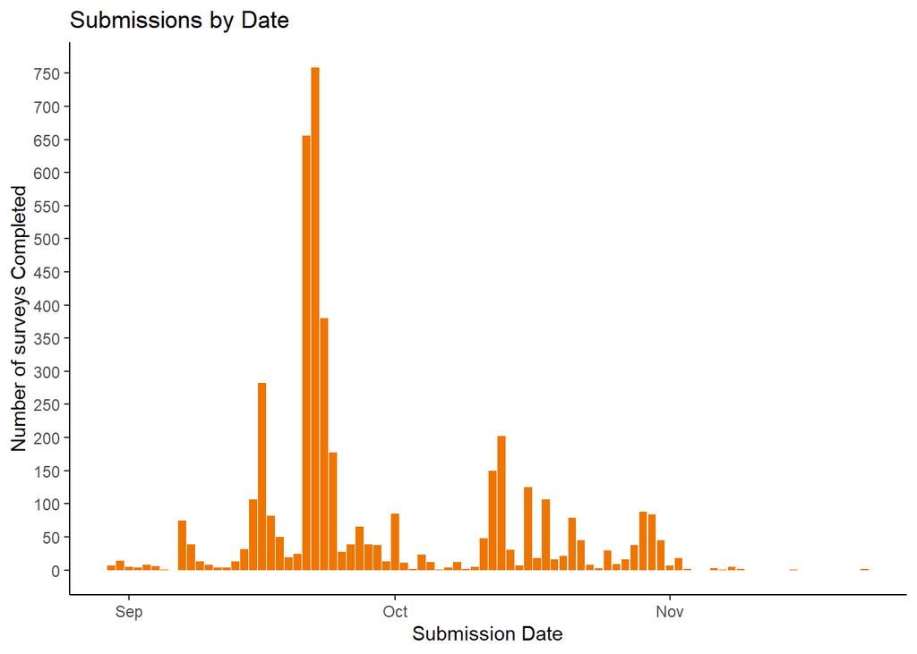